# Data Engineering with a Complex Football Database

Big Data has been revolutionary for football clubs all around the world this last decade. For example, a team of scientists specialized in data have been, in part, responsibles of the great recruitment moves from Liverpool FC that have led them to win the Premier League after 30 long years. It can guide in which player to sign, what are the most important problems in the club, performance analysis, fitness optimization...

In this project, we are going to build two models that will predict two different things: market value of players, and if a team is going to classify for some european competition. These will make use of two different datasets with also different sources.

The first model will be a Linear Regression model for predicting the market value of a player after a season considering as predictors his stats, like goals or assists. The second model will be a Generalized Linear Model for predicting whether a football team is going to classify to Champions League (UCL), Europa League (UEL) or Conference League (UECL).

First, we are going to import here all the libraries used along the project:

```python
import numpy as np
import pandas as pd
import seaborn as sns
import matplotlib.pyplot as plt
from datetime import datetime
from itertools import combinations
from io import StringIO

import statsmodels.api as sm
import statsmodels.formula.api as smf

from statsmodels.stats.outliers_influence import variance_inflation_factor
from statsmodels.stats.diagnostic import het_breuschpagan

from sklearn.model_selection import train_test_split
from sklearn.linear_model import LinearRegression
from sklearn.metrics import mean_squared_error, r2_score
from sklearn.preprocessing import StandardScaler
from sklearn.decomposition import PCA
from sklearn.metrics import confusion_matrix, accuracy_score

pd.set_option('display.max_columns', None)
pd.options.mode.chained_assignment = None
```

## 1. Linear regression: predicting market values

Transfermarkt is a database of football with updated data about games, players, clubs and market valuations, with reliable and updated data about all type of stats. However, it is mainly know for its market value data as it is pretty accurate. Using this tool, we can know the value of a certain player whenever we want, without having to wait for him to be transferred to another club. We are going to use this for the first part of the project: the linear regression model. Next, we are going to explain our goals, how we are going to obtain the data and our linear regression model.

**Goal**: predict the market value of an attacker for LaLiga after a full season (as there is a very high number of players in the dataset, we will restrict it to attackers from LaLiga, Spanish top domestic league).

**Predictors**: public data available in the Transfermarkt database.

**Dataset**: the source code that scrapes the data from Transfermarkt is in https://github.com/dcaribou/transfermarkt-datasets, and the final datasets can be obtained through Kaggle (https://www.kaggle.com/datasets/davidcariboo/player-scores).

### Data preparation and explanation

#### Datasets

The datasets used for this part are *appearances*, *games*, *players* and *player_valuations*. We will need to combine them to obtain our final dataset. Here we import them and we take a look at them:

```python
appearances = pd.read_csv('appearances.csv')
games = pd.read_csv('games.csv')
players = pd.read_csv('players.csv')
player_valuations = pd.read_csv('player_valuations.csv')
```

**Appearances**

This dataset has a row per each appearance for a player in a match. We will use it to calculate the stats (goals, assists, minutes played...) for a player in a season, as it is the only dataset that has this stats. The used keys are: *game_id*, *player_id*.

```python
appearances.head()
```

|  | appearance_id | game_id | player_id | player_club_id | player_current_club_id | date | player_name | competition_id | yellow_cards | red_cards | goals | assists | minutes_played |
| --- | --- | --- | --- | --- | --- | --- | --- | --- | --- | --- | --- | --- | --- |
| 0 | 2231978_38004 | 2231978 | 38004 | 853 | 235 | 2012-07-03 | Aurélien Joachim | CLQ | 0 | 0 | 2 | 0 | 90 |
| 1 | 2233748_79232 | 2233748 | 79232 | 8841 | 2698 | 2012-07-05 | Ruslan Abyshov | ELQ | 0 | 0 | 0 | 0 | 90 |
| 2 | 2234413_42792 | 2234413 | 42792 | 6251 | 465 | 2012-07-05 | Sander Puri | ELQ | 0 | 0 | 0 | 0 | 45 |
| 3 | 2234418_73333 | 2234418 | 73333 | 1274 | 6646 | 2012-07-05 | Vegar Hedenstad | ELQ | 0 | 0 | 0 | 0 | 90 |
| 4 | 2234421_122011 | 2234421 | 122011 | 195 | 3008 | 2012-07-05 | Markus Henriksen | ELQ | 0 | 0 | 0 | 1 | 90 |

**Games**

This dataset has a row per each match registered in the database. We will join it to the *appearances* dataset to get information (home club goals, away club goals...) for each match. The used key is *game_id*.

```python
games.head()
```

|  | game_id | competition_id | season | round | date | home_club_id | away_club_id | home_club_goals | away_club_goals | home_club_position | away_club_position | home_club_manager_name | away_club_manager_name | stadium | attendance | referee | url | home_club_formation | away_club_formation | home_club_name | away_club_name | aggregate | competition_type |
| --- | --- | --- | --- | --- | --- | --- | --- | --- | --- | --- | --- | --- | --- | --- | --- | --- | --- | --- | --- | --- | --- | --- | --- |
| 0 | 2321044 | L1 | 2013 | 2. Matchday | 2013-08-18 | 16 | 23 | 2 | 1 | 1.0 | 15.0 | Jürgen Klopp | Torsten Lieberknecht | SIGNAL IDUNA PARK | 80200.0 | Peter Sippel | https://www.transfermarkt.co.uk/borussia-dortm... | 4-2-3-1 | 4-3-2-1 | Borussia Dortmund | Eintracht Braunschweig | 2:1 | domestic_league |
| 1 | 2321060 | L1 | 2013 | 3. Matchday | 2013-08-25 | 23 | 24 | 0 | 2 | 18.0 | 11.0 | Torsten Lieberknecht | Armin Veh | EINTRACHT-Stadion | 23325.0 | Wolfgang Stark | https://www.transfermarkt.co.uk/eintracht-brau... | 4-3-2-1 | 4-2-3-1 | Eintracht Braunschweig | Eintracht Frankfurt Fußball AG | 0:2 | domestic_league |
| 2 | 2321086 | L1 | 2013 | 6. Matchday | 2013-09-21 | 4 | 16 | 1 | 1 | 15.0 | 1.0 | Michael Wiesinger | Jürgen Klopp | Max-Morlock-Stadion | 50000.0 | Knut Kircher | https://www.transfermarkt.co.uk/1-fc-nuremberg... | 4-2-3-1 | 4-2-3-1 | 1.FC Nuremberg | Borussia Dortmund | 1:1 | domestic_league |
| 3 | 2321152 | L1 | 2013 | 11. Matchday | 2013-11-02 | 44 | 33 | 0 | 2 | 7.0 | 6.0 | Jos Luhukay | Jens Keller | Olympiastadion Berlin | 69277.0 | Günter Perl | https://www.transfermarkt.co.uk/hertha-bsc_fc-... | 4-2-3-1 | 4-2-3-1 | Hertha BSC | FC Schalke 04 | 0:2 | domestic_league |
| 4 | 2321205 | L1 | 2013 | 17. Matchday | 2013-12-21 | 41 | 39 | 2 | 3 | 14.0 | 9.0 | Bert van Marwijk | Thomas Tuchel | Volksparkstadion | 50000.0 | Bastian Dankert | https://www.transfermarkt.co.uk/hamburger-sv_1... | 4-2-3-1 | 4-4-2 Diamond | Hamburger SV | 1. Fußball- und Sportverein Mainz 05 | 2:3 | domestic_league |

**Players**

This dataset has a row per each player registered in the database. We will to get more information about each players. The used key is *player_id*.

```python
players.head()
```

|  | player_id | first_name | last_name | name | last_season | current_club_id | player_code | country_of_birth | city_of_birth | country_of_citizenship | date_of_birth | sub_position | position | foot | height_in_cm | contract_expiration_date | agent_name | image_url | url | current_club_domestic_competition_id | current_club_name | market_value_in_eur | highest_market_value_in_eur |
| --- | --- | --- | --- | --- | --- | --- | --- | --- | --- | --- | --- | --- | --- | --- | --- | --- | --- | --- | --- | --- | --- | --- | --- |
| 0 | 10 | Miroslav | Klose | Miroslav Klose | 2015 | 398 | miroslav-klose | Poland | Opole | Germany | 1978-06-09 00:00:00 | Centre-Forward | Attack | right | 184.0 | NaN | ASBW Sport Marketing | https://img.a.transfermarkt.technology/portrai... | https://www.transfermarkt.co.uk/miroslav-klose... | IT1 | Società Sportiva Lazio S.p.A. | 1000000.0 | 30000000.0 |
| 1 | 26 | Roman | Weidenfeller | Roman Weidenfeller | 2017 | 16 | roman-weidenfeller | Germany | Diez | Germany | 1980-08-06 00:00:00 | Goalkeeper | Goalkeeper | left | 190.0 | NaN | Neubauer 13 GmbH | https://img.a.transfermarkt.technology/portrai... | https://www.transfermarkt.co.uk/roman-weidenfe... | L1 | Borussia Dortmund | 750000.0 | 8000000.0 |
| 2 | 65 | Dimitar | Berbatov | Dimitar Berbatov | 2015 | 1091 | dimitar-berbatov | Bulgaria | Blagoevgrad | Bulgaria | 1981-01-30 00:00:00 | Centre-Forward | Attack | NaN | NaN | NaN | CSKA-AS-23 Ltd. | https://img.a.transfermarkt.technology/portrai... | https://www.transfermarkt.co.uk/dimitar-berbat... | GR1 | Panthessalonikios Athlitikos Omilos Konstantin... | 1000000.0 | 34500000.0 |
| 3 | 77 | NaN | Lúcio | Lúcio | 2012 | 506 | lucio | Brazil | Brasília | Brazil | 1978-05-08 00:00:00 | Centre-Back | Defender | NaN | NaN | NaN | NaN | https://img.a.transfermarkt.technology/portrai... | https://www.transfermarkt.co.uk/lucio/profil/s... | IT1 | Juventus Football Club | 200000.0 | 24500000.0 |
| 4 | 80 | Tom | Starke | Tom Starke | 2017 | 27 | tom-starke | East Germany (GDR) | Freital | Germany | 1981-03-18 00:00:00 | Goalkeeper | Goalkeeper | right | 194.0 | NaN | IFM | https://img.a.transfermarkt.technology/portrai... | https://www.transfermarkt.co.uk/tom-starke/pro... | L1 | FC Bayern München | 100000.0 | 3000000.0 |

**Player valuations**

This dataset has a registers of the market value of a player for some dates. We will use it to calculate the market value for a player in each season. The used key is *player_id*.

```python
player_valuations.head()
```

|  | player_id | date | market_value_in_eur | current_club_id | player_club_domestic_competition_id |
| --- | --- | --- | --- | --- | --- |
| 0 | 405973 | 2000-01-20 | 150000 | 3057 | BE1 |
| 1 | 342216 | 2001-07-20 | 100000 | 1241 | SC1 |
| 2 | 3132 | 2003-12-09 | 400000 | 126 | TR1 |
| 3 | 6893 | 2003-12-15 | 900000 | 984 | GB1 |
| 4 | 10 | 2004-10-04 | 7000000 | 398 | IT1 |

#### Filter data

Our database is going to be composed of just attackers from LaLiga (the spanish 1st division).

```python
# Keep only attack players
players = players[players['position'] == 'Attack']
```

```python
# Get the match_stats for LaLiga matches with a left join of appearances with games
match_stats = appearances.merge(games, on='game_id', how='left')

# Keep only LaLiga matches
match_stats_laliga = match_stats[match_stats['competition_id_x'] == 'ES1']
```

#### Compose the dataset

Our desired dataset has a row per player and season, and has the values of the predictors and the market value of that season.

```python
# This function creates a dataframe with one row with the player stats for a season
def player_stats(player_id, season, df):

    # Create a dataframe with one row for a player with player_id and season
    df = df[df['player_id'] == player_id]
    df = df[df['season'] == season]

    # If there is no data, returns a NaN ID and zeros
    if (df.shape[0] == 0):
        Out = [(np.nan, season,0,0,0,0,0,0,0)]
        out_df = pd.DataFrame(data = Out, columns = ['player_id','season','goals','games',
                                                     'assists','minutes_played','goals_for','goals_against','clean_sheet'])
        return out_df

    # If there is data, append it
    else:

        # These is the data for the player club, that checks if the club was at home or away for computing it
        df["goals_for"] = df.apply(lambda row: row['home_club_goals'] if row['home_club_id'] == row['player_club_id']
                      else row['away_club_goals'] if row['away_club_id'] == row['player_club_id']
                      else np.nan, axis=1)
        df["goals_against"] = df.apply(lambda row: row['away_club_goals'] if row['home_club_id'] == row['player_club_id']
                      else row['home_club_goals'] if row['away_club_id'] == row['player_club_id']
                      else np.nan, axis=1)
        df['clean_sheet'] = df.apply(lambda row: 1 if row['goals_against'] == 0
                      else 0 if row['goals_against'] > 0
                      else np.nan, axis=1)

        # Group by player and season, and record the data
        df = df.groupby(['player_id',"season", 'player_name'],as_index=False).agg({'goals': 'sum', 'game_id': 'nunique',
                                                                      'assists': 'sum', 'minutes_played' : 'sum', 'goals_for' : 'sum',
                                                                      'goals_against' : 'sum', 'clean_sheet' : 'sum'})
        out_df = df.rename(columns={'game_id': 'games'})

        return out_df
```

We will select seasons from 2016-2017 to 2023-2024, so we have a big dataset (8 full seasons).

```python
# We define the start and end season for our analisis
start_season = 2016  # Corresponds to 2016-2017
end_season = 2023

# Apply the function to all desired players and all the specified seasons
dfs = []
for season in range(start_season, end_season+1):

    for id in players['player_id']:

        dfs.append(player_stats(id, season, match_stats_laliga))

stats = pd.concat(dfs, ignore_index=True).dropna(subset=['player_id'])
```

The resulting dataset is:

```python
stats.head()
```

|  | player_id | season | goals | games | assists | minutes_played | goals_for | goals_against | clean_sheet | player_name |
| --- | --- | --- | --- | --- | --- | --- | --- | --- | --- | --- |
| 151 | 7663.0 | 2016 | 3 | 28 | 4 | 1678 | 30 | 47 | 7 | Joaquín |
| 152 | 7717.0 | 2016 | 3 | 21 | 4 | 865 | 30 | 27 | 8 | José Antonio Reyes |
| 153 | 7767.0 | 2016 | 8 | 31 | 6 | 1418 | 58 | 22 | 15 | Fernando Torres |
| 169 | 8198.0 | 2016 | 25 | 29 | 6 | 2544 | 75 | 31 | 7 | Cristiano Ronaldo |
| 291 | 15568.0 | 2016 | 0 | 22 | 1 | 1451 | 23 | 31 | 6 | Bruno Gama |

With the following number of rows:

```python
len(stats)
```

```
1359
```

For example, we can check the data from the players Lionel Messi (player_id = 28003) or Kylian Mbappé (player_id = 342229) to see that it is accurate:

```python
stats[stats['player_id'] == 28003]
```

|  | player_id | season | goals | games | assists | minutes_played | goals_for | goals_against | clean_sheet | player_name |
| --- | --- | --- | --- | --- | --- | --- | --- | --- | --- | --- |
| 493 | 28003.0 | 2016 | 37 | 34 | 12 | 2832 | 104 | 32 | 11 | Lionel Messi |
| 9356 | 28003.0 | 2017 | 34 | 36 | 14 | 2996 | 93 | 24 | 18 | Lionel Messi |
| 18219 | 28003.0 | 2018 | 36 | 34 | 14 | 2710 | 82 | 31 | 16 | Lionel Messi |
| 27082 | 28003.0 | 2019 | 25 | 33 | 22 | 2880 | 72 | 31 | 14 | Lionel Messi |
| 35945 | 28003.0 | 2020 | 30 | 35 | 11 | 3023 | 81 | 37 | 12 | Lionel Messi |

```python
stats[stats['player_id'] == 342229]
```

|  | player_id | season | goals | games | assists | minutes_played | goals_for | goals_against | clean_sheet | player_name |
| --- | --- | --- | --- | --- | --- | --- | --- | --- | --- | --- |

These is reasonable, as Lionel Messi left LaLiga in 2021 and Kylian Mbappé first season has been 2024, which is not in our analysis as it has not finished yet.

Now, we add information about each player with a left join with the *players* dataset:

```python
stats = pd.merge(stats, players[['player_id', 'date_of_birth', 'sub_position', 'foot', 'height_in_cm', 'highest_market_value_in_eur']], on='player_id', how='left')
stats.head()
```

|  | player_id | season | goals | games | assists | minutes_played | goals_for | goals_against | clean_sheet | player_name | date_of_birth | sub_position | foot | height_in_cm | highest_market_value_in_eur |
| --- | --- | --- | --- | --- | --- | --- | --- | --- | --- | --- | --- | --- | --- | --- | --- |
| 0 | 7663.0 | 2016 | 3 | 28 | 4 | 1678 | 30 | 47 | 7 | Joaquín | 1981-07-21 00:00:00 | Right Winger | right | 181.0 | 28000000.0 |
| 1 | 7717.0 | 2016 | 3 | 21 | 4 | 865 | 30 | 27 | 8 | José Antonio Reyes | 1983-09-01 00:00:00 | Right Winger | left | 176.0 | 35000000.0 |
| 2 | 7767.0 | 2016 | 8 | 31 | 6 | 1418 | 58 | 22 | 15 | Fernando Torres | 1984-03-20 00:00:00 | Centre-Forward | right | 186.0 | 50000000.0 |
| 3 | 8198.0 | 2016 | 25 | 29 | 6 | 2544 | 75 | 31 | 7 | Cristiano Ronaldo | 1985-02-05 00:00:00 | Centre-Forward | right | 187.0 | 120000000.0 |
| 4 | 15568.0 | 2016 | 0 | 22 | 1 | 1451 | 23 | 31 | 6 | Bruno Gama | 1987-11-15 00:00:00 | Left Winger | right | 175.0 | 4000000.0 |

And we can calculate the current age and the age in each season using the date of birth:

```python
stats['date_of_birth'] = pd.to_datetime(stats['date_of_birth'])
# drop players with no date of birth (2 records only)
stats = stats[stats['date_of_birth'].isnull() == False]
now = datetime.now()
stats['current_age'] = (now - stats['date_of_birth']).apply(lambda x: x.days) / 365.25
stats['current_age'] = stats['current_age'].round().astype(int)
stats['age'] = stats['current_age'] - 2024 + stats['season']
```

As our dependent variable is the market value, we have to use the *player_valuations* dataset to get it. For a certain player, it looks like this:

```python
player_valuations[player_valuations['player_id'] == 342229].sort_values('date').head()
```

|  | player_id | date | market_value_in_eur | current_club_id | player_club_domestic_competition_id |
| --- | --- | --- | --- | --- | --- |
| 155631 | 342229 | 2015-12-02 | 50000 | 418 | ES1 |
| 161699 | 342229 | 2016-02-04 | 250000 | 418 | ES1 |
| 167551 | 342229 | 2016-04-09 | 1000000 | 418 | ES1 |
| 173911 | 342229 | 2016-07-13 | 1500000 | 418 | ES1 |
| 184542 | 342229 | 2016-11-01 | 4000000 | 418 | ES1 |

So we are going to take the average market value for each player and season with a group by:

```python
# Keep only the year
player_valuations['season'] = player_valuations['date'].str[:4].astype('int')

# Group by player and season, and compute the mean
value_per_year = player_valuations.groupby(['player_id', 'season'])['market_value_in_eur'].mean().reset_index()

# Inner join with the stats dataframe, as we want rows with both information (dependent and independent variables)
stats = pd.merge(stats, value_per_year, on=['player_id', 'season'], how='inner')
stats.head()
```

|  | player_id | season | goals | games | assists | minutes_played | goals_for | goals_against | clean_sheet | player_name | date_of_birth | sub_position | foot | height_in_cm | highest_market_value_in_eur | current_age | age | market_value_in_eur |
| --- | --- | --- | --- | --- | --- | --- | --- | --- | --- | --- | --- | --- | --- | --- | --- | --- | --- | --- |
| 0 | 7663.0 | 2016 | 3 | 28 | 4 | 1678 | 30 | 47 | 7 | Joaquín | 1981-07-21 | Right Winger | right | 181.0 | 28000000.0 | 43 | 35 | 1000000.0 |
| 1 | 7717.0 | 2016 | 3 | 21 | 4 | 865 | 30 | 27 | 8 | José Antonio Reyes | 1983-09-01 | Right Winger | left | 176.0 | 35000000.0 | 41 | 33 | 2000000.0 |
| 2 | 7767.0 | 2016 | 8 | 31 | 6 | 1418 | 58 | 22 | 15 | Fernando Torres | 1984-03-20 | Centre-Forward | right | 186.0 | 50000000.0 | 41 | 33 | 8500000.0 |
| 3 | 8198.0 | 2016 | 25 | 29 | 6 | 2544 | 75 | 31 | 7 | Cristiano Ronaldo | 1985-02-05 | Centre-Forward | right | 187.0 | 120000000.0 | 40 | 32 | 110000000.0 |
| 4 | 15568.0 | 2016 | 0 | 22 | 1 | 1451 | 23 | 31 | 6 | Bruno Gama | 1987-11-15 | Left Winger | right | 175.0 | 4000000.0 | 37 | 29 | 2000000.0 |

Now, we are going to add another stat: the number of Champions League matches, as this number is probably correlated to the market value of a player (Champions League is the top clubs competition). To do it, we will use the match stats for CL matches, count the appearances for each player and add this count to our dataset.

```python
# Get the count of CL matches played
match_stats_champions = match_stats[match_stats['competition_id_x'] == 'CL']
champions_counts = match_stats_champions.groupby('player_id').size().reset_index(name='cl_matches')
stats = pd.merge(stats, champions_counts, on=['player_id'], how='left')

# Some players with 0 matches have NaN, so we fill them:
stats['cl_matches'] = stats['cl_matches'].fillna(0)

stats.head()
```

|  | player_id | season | goals | games | assists | minutes_played | goals_for | goals_against | clean_sheet | player_name | date_of_birth | sub_position | foot | height_in_cm | highest_market_value_in_eur | current_age | age | market_value_in_eur | cl_matches |
| --- | --- | --- | --- | --- | --- | --- | --- | --- | --- | --- | --- | --- | --- | --- | --- | --- | --- | --- | --- |
| 0 | 7663.0 | 2016 | 3 | 28 | 4 | 1678 | 30 | 47 | 7 | Joaquín | 1981-07-21 | Right Winger | right | 181.0 | 28000000.0 | 43 | 35 | 1000000.0 | 8.0 |
| 1 | 7717.0 | 2016 | 3 | 21 | 4 | 865 | 30 | 27 | 8 | José Antonio Reyes | 1983-09-01 | Right Winger | left | 176.0 | 35000000.0 | 41 | 33 | 2000000.0 | 2.0 |
| 2 | 7767.0 | 2016 | 8 | 31 | 6 | 1418 | 58 | 22 | 15 | Fernando Torres | 1984-03-20 | Centre-Forward | right | 186.0 | 50000000.0 | 41 | 33 | 8500000.0 | 44.0 |
| 3 | 8198.0 | 2016 | 25 | 29 | 6 | 2544 | 75 | 31 | 7 | Cristiano Ronaldo | 1985-02-05 | Centre-Forward | right | 187.0 | 120000000.0 | 40 | 32 | 110000000.0 | 103.0 |
| 4 | 15568.0 | 2016 | 0 | 22 | 1 | 1451 | 23 | 31 | 6 | Bruno Gama | 1987-11-15 | Left Winger | right | 175.0 | 4000000.0 | 37 | 29 | 2000000.0 | 0.0 |

Next, we want to add some dummy values to categorical variables. For subposition and foot, we have the following values:

```python
stats['sub_position'].unique()
```

```
array(['Right Winger', 'Centre-Forward', 'Left Winger', 'Second Striker'],
      dtype=object)
```

```python
stats['foot'].unique()
```

```
array(['right', 'left', 'both', nan], dtype=object)
```

Creating the dummies:

```python
stats['Winger'] = stats['sub_position'].apply(lambda x: 1 if 'Winger' in x else 0)
stats['Striker'] = stats['sub_position'].apply(lambda x: 1 if 'Winger' not in x else 0)

stats['Left_footed'] = stats['foot'].apply(lambda x: 1 if isinstance(x, str) and ('left' in x or 'both' in x) else 0)
stats['Right_footed'] = stats['foot'].apply(lambda x: 1 if isinstance(x, str) and ('right' in x or 'both' in x) else 0)
```

```python
stats.head()
```

|  | player_id | season | goals | games | assists | minutes_played | goals_for | goals_against | clean_sheet | player_name | date_of_birth | sub_position | foot | height_in_cm | highest_market_value_in_eur | current_age | age | market_value_in_eur | cl_matches | Winger | Striker | Left_footed | Right_footed |
| --- | --- | --- | --- | --- | --- | --- | --- | --- | --- | --- | --- | --- | --- | --- | --- | --- | --- | --- | --- | --- | --- | --- | --- |
| 0 | 7663.0 | 2016 | 3 | 28 | 4 | 1678 | 30 | 47 | 7 | Joaquín | 1981-07-21 | Right Winger | right | 181.0 | 28000000.0 | 43 | 35 | 1000000.0 | 8.0 | 1 | 0 | 0 | 1 |
| 1 | 7717.0 | 2016 | 3 | 21 | 4 | 865 | 30 | 27 | 8 | José Antonio Reyes | 1983-09-01 | Right Winger | left | 176.0 | 35000000.0 | 41 | 33 | 2000000.0 | 2.0 | 1 | 0 | 1 | 0 |
| 2 | 7767.0 | 2016 | 8 | 31 | 6 | 1418 | 58 | 22 | 15 | Fernando Torres | 1984-03-20 | Centre-Forward | right | 186.0 | 50000000.0 | 41 | 33 | 8500000.0 | 44.0 | 0 | 1 | 0 | 1 |
| 3 | 8198.0 | 2016 | 25 | 29 | 6 | 2544 | 75 | 31 | 7 | Cristiano Ronaldo | 1985-02-05 | Centre-Forward | right | 187.0 | 120000000.0 | 40 | 32 | 110000000.0 | 103.0 | 0 | 1 | 0 | 1 |
| 4 | 15568.0 | 2016 | 0 | 22 | 1 | 1451 | 23 | 31 | 6 | Bruno Gama | 1987-11-15 | Left Winger | right | 175.0 | 4000000.0 | 37 | 29 | 2000000.0 | 0.0 | 1 | 0 | 0 | 1 |

Drop the columns that we are not going to use:

```python
stats = stats.drop(columns=['player_name', 'date_of_birth', 'sub_position', 'foot', 'age'])
```

Check for NaNs:

```python
has_nans = stats.isna().any().any()
print(f"Does the DataFrame contain NaNs? {has_nans}")
```

```
Does the DataFrame contain NaNs? True
```

```python
nan_counts = stats.isna().sum()
print("NaN count per column:")
print(nan_counts)
```

```
NaN count per column:
player_id                      0
season                         0
goals                          0
games                          0
assists                        0
minutes_played                 0
goals_for                      0
goals_against                  0
clean_sheet                    0
height_in_cm                   2
highest_market_value_in_eur    0
current_age                    0
market_value_in_eur            0
cl_matches                     0
Winger                         0
Striker                        0
Left_footed                    0
Right_footed                   0
dtype: int64
```

We can fill the NaN values in the *height* column by the mean of the column:

```python
stats['height_in_cm'] = stats['height_in_cm'].fillna(stats['height_in_cm'].mean())
```

And finally we have our dataset, ready for predictive analysis:

```python
stats.head()
```

|  | player_id | season | goals | games | assists | minutes_played | goals_for | goals_against | clean_sheet | height_in_cm | highest_market_value_in_eur | current_age | market_value_in_eur | cl_matches | Winger | Striker | Left_footed | Right_footed |
| --- | --- | --- | --- | --- | --- | --- | --- | --- | --- | --- | --- | --- | --- | --- | --- | --- | --- | --- |
| 0 | 7663.0 | 2016 | 3 | 28 | 4 | 1678 | 30 | 47 | 7 | 181.0 | 28000000.0 | 43 | 1000000.0 | 8.0 | 1 | 0 | 0 | 1 |
| 1 | 7717.0 | 2016 | 3 | 21 | 4 | 865 | 30 | 27 | 8 | 176.0 | 35000000.0 | 41 | 2000000.0 | 2.0 | 1 | 0 | 1 | 0 |
| 2 | 7767.0 | 2016 | 8 | 31 | 6 | 1418 | 58 | 22 | 15 | 186.0 | 50000000.0 | 41 | 8500000.0 | 44.0 | 0 | 1 | 0 | 1 |
| 3 | 8198.0 | 2016 | 25 | 29 | 6 | 2544 | 75 | 31 | 7 | 187.0 | 120000000.0 | 40 | 110000000.0 | 103.0 | 0 | 1 | 0 | 1 |
| 4 | 15568.0 | 2016 | 0 | 22 | 1 | 1451 | 23 | 31 | 6 | 175.0 | 4000000.0 | 37 | 2000000.0 | 0.0 | 1 | 0 | 0 | 1 |

```python
stats.columns
```

```
Index(['player_id', 'season', 'goals', 'games', 'assists', 'minutes_played',
       'goals_for', 'goals_against', 'clean_sheet', 'height_in_cm',
       'highest_market_value_in_eur', 'current_age', 'market_value_in_eur',
       'cl_matches', 'Winger', 'Striker', 'Left_footed', 'Right_footed'],
      dtype='object')
```

### Exploratory analysis

#### Correlation between variables

Let's see the correlation between variables with a heatmap:

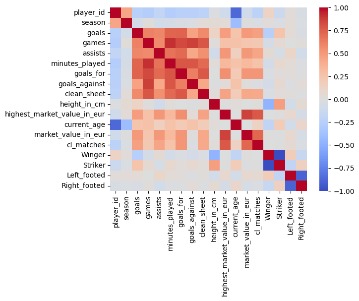

```python
sns.heatmap(stats.corr(), cmap='coolwarm', center=0)
```

We are interested in the correlations between *market_value_in_eur* and the rest of variables. We see that there is positive correlations for it with the following variables:

- goals
- games
- assists
- minutes_played
- goals_for
- clean_sheet
- highest_market_value_in_eur
- cl_matches

So we are going to take just this columns for the linear regression.

We have not found correlations between market value and *player_id* (obviously), *season* (seems that inflation is not a factor to consider with just 8 seasons), height, age, position and preferred foot. However, they have some reasonable and interesting correlation with other variables, like height being positive correlated to being striker and negative correlated to being winger, as strikers are usually tall and strong while wingers are usually shorter and faster.

```python
columns_for_lr = ['market_value_in_eur', 'goals', 'games', 'assists', 'minutes_played', 'goals_for', 'clean_sheet', 'highest_market_value_in_eur', 'cl_matches']
lr_df = stats[columns_for_lr]
lr_df.head()
```

|  | market_value_in_eur | goals | games | assists | minutes_played | goals_for | clean_sheet | highest_market_value_in_eur | cl_matches |
| --- | --- | --- | --- | --- | --- | --- | --- | --- | --- |
| 0 | 1000000.0 | 3 | 28 | 4 | 1678 | 30 | 7 | 28000000.0 | 8.0 |
| 1 | 2000000.0 | 3 | 21 | 4 | 865 | 30 | 8 | 35000000.0 | 2.0 |
| 2 | 8500000.0 | 8 | 31 | 6 | 1418 | 58 | 15 | 50000000.0 | 44.0 |
| 3 | 110000000.0 | 25 | 29 | 6 | 2544 | 75 | 7 | 120000000.0 | 103.0 |
| 4 | 2000000.0 | 0 | 22 | 1 | 1451 | 23 | 6 | 4000000.0 | 0.0 |

Plotting them again in a heatmap so we can see more clearly the relationship between them:

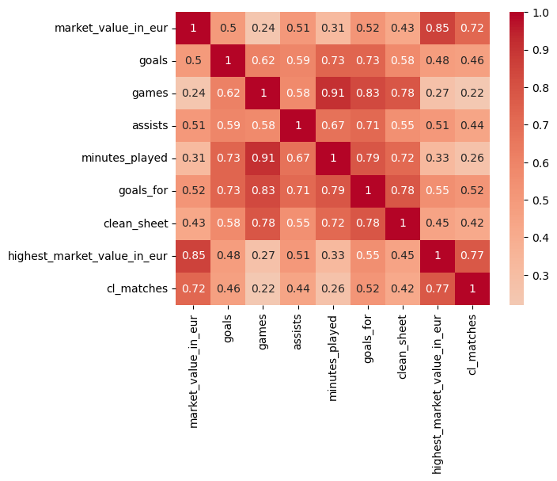

```python
sns.heatmap(lr_df.corr(), cmap='coolwarm', center=0, annot=True)
```

Here we see that there is also a strong correlation between the following variables:

- goals
- games
- assists
- minutes_played
- goals_for
- clean_sheet

We will consider this in the future calculations.

We can plot scatterplots of our dependent variable *market_value_in_eur* vs. the predictors:

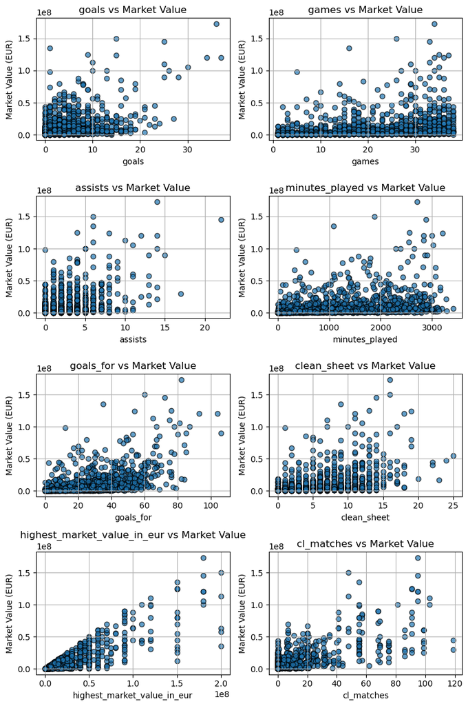

```python
# Define the columns to be plotted on the x-axis
predictors = ['goals', 'games', 'assists', 'minutes_played', 'goals_for', 'clean_sheet', 'highest_market_value_in_eur', 'cl_matches']

# Set up the 4x2 grid
fig, axes = plt.subplots(4, 2, figsize=(8, 12))
axes = axes.ravel()  # Flatten the 4x2 grid into a 1D array for easier iteration

# Create scatterplots
for i, col in enumerate(predictors):
    ax = axes[i]
    ax.scatter(lr_df[col], lr_df['market_value_in_eur'], alpha=0.7, edgecolor='k')
    ax.set_title(f'{col} vs Market Value')
    ax.set_xlabel(col)
    ax.set_ylabel('Market Value (EUR)')
    ax.grid(True)

# Adjust layout to prevent overlap
plt.tight_layout()
```

We see positive correlations between all of them. However, visualizing them well is complicated, as most players have low market values compared with the maximum values. Next, we are going to get some information about our variables so we can better understand our dataset.

#### Distributions of variables

If we plot a histogram of market values, we can check that most of the players have low market values and these decrease exponentially.

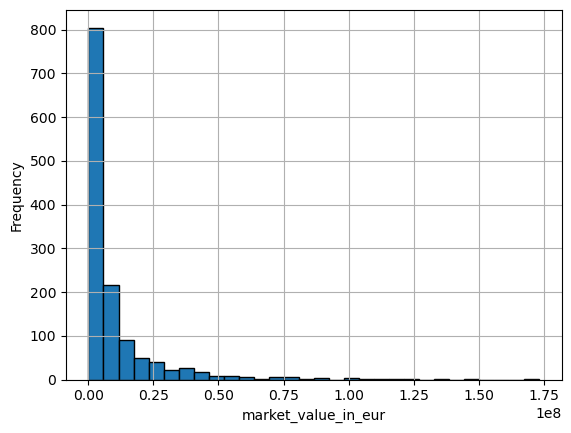

```python
plt.hist(lr_df['market_value_in_eur'], bins=30, edgecolor='k')
plt.xlabel('market_value_in_eur')
plt.ylabel('Frequency')
plt.grid()
```

```python
print(f"Life expectancy mean and std: {lr_df['market_value_in_eur'].mean()} ± {lr_df['market_value_in_eur'].std()}")
```

```
Life expectancy mean and std: 10429402.424111638 ± 18345050.537691157
```

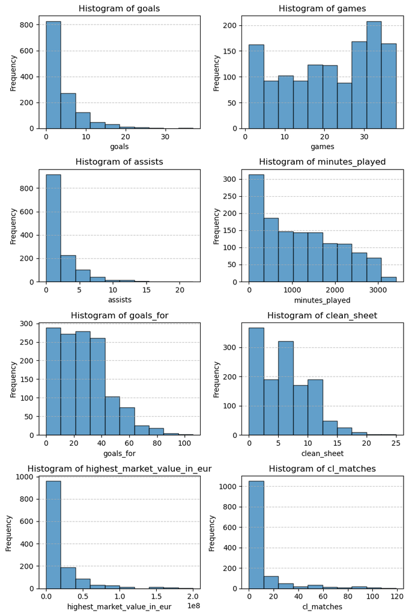

```python
# Set up the 4x2 grid for histograms
fig, axes = plt.subplots(4, 2, figsize=(8, 12))
axes = axes.ravel()  # Flatten the 4x2 grid into a 1D array for easier iteration

# Create histograms
for i, col in enumerate(predictors):  # Use the same `x_columns` from before
    ax = axes[i]
    ax.hist(lr_df[col], bins=10, edgecolor='k', alpha=0.7)
    ax.set_title(f'Histogram of {col}')
    ax.set_xlabel(col)
    ax.set_ylabel('Frequency')
    ax.grid(axis='y', linestyle='--', alpha=0.7)

# Adjust layout to prevent overlap
plt.tight_layout()
plt.show()
```

### Predictive analysis

For our predictive analysis we will use the *sm* library, that provides us with the functionalities of R in python.

#### Standard linear regression

For this part, we will do a standard linear regression without taking into consideration interaction between variables. Then we will consider it and see how the results change, so we can understand better our data and our model.

We have already defined our predictors:

```python
print(predictors)
```

```
['goals', 'games', 'assists', 'minutes_played', 'goals_for', 'clean_sheet', 'highest_market_value_in_eur', 'cl_matches']
```

Let's create the datasets used and split them into train (80%) and test (20%) batches. We will also divide the market value between $10^6$ so it is easier to read, as it will be in millions.

```python
X = lr_df[predictors]
y = lr_df['market_value_in_eur']/10**6  # Market value in millions
X = sm.add_constant(X)

X_train, X_test, y_train, y_test = train_test_split(X, y, test_size = 0.2, random_state = 1)
```

```python
model = sm.OLS(y_train, X_train).fit()
print(model.summary())
```

```
                             OLS Regression Results
===============================================================================
Dep. Variable:     market_value_in_eur   R-squared:                       0.766
Model:                             OLS   Adj. R-squared:                  0.764
Method:                  Least Squares   F-statistic:                     428.9
Date:                 Sun, 15 Dec 2024   Prob (F-statistic):               0.00
Time:                         23:14:36   Log-Likelihood:                -3790.1
No. Observations:                 1059   AIC:                             7598.
Df Residuals:                     1050   BIC:                             7643.
Df Model:                            8
Covariance Type:             nonrobust
===============================================================================================
                                  coef    std err          t      P>|t|      [0.025      0.975]
-----------------------------------------------------------------------------------------------
const                           1.2863      0.611      2.104      0.036       0.087       2.486
goals                           0.2577      0.095      2.717      0.007       0.072       0.444
games                          -0.3616      0.081     -4.477      0.000      -0.520      -0.203
assists                         0.4830      0.171      2.827      0.005       0.148       0.818
minutes_played                  0.0012      0.001      1.302      0.193      -0.001       0.003
goals_for                       0.0832      0.042      2.000      0.046       0.002       0.165
clean_sheet                     0.3219      0.111      2.890      0.004       0.103       0.540
highest_market_value_in_eur  3.954e-07   1.54e-08     25.707      0.000    3.65e-07    4.26e-07
cl_matches                      0.1120      0.024      4.752      0.000       0.066       0.158
==============================================================================
Omnibus:                      218.516   Durbin-Watson:                   2.042
Prob(Omnibus):                  0.000   Jarque-Bera (JB):             4093.075
Skew:                           0.399   Prob(JB):                         0.00
Kurtosis:                      12.598   Cond. No.                     8.32e+07
==============================================================================

Notes:
[1] Standard Errors assume that the covariance matrix of the errors is correctly specified.
[2] The condition number is large, 8.32e+07. This might indicate that there are
strong multicollinearity or other numerical problems.
```

```python
y_pred = model.predict(X_test)
r2_test = r2_score(y_test, y_pred)
print(f"Test R^2: {r2_test}")
```

```
Test R^2: 0.7084857305940933
```

We can see that the results are satisfactory, with an $R^2 \approx 0.71$. However, we want to adress two things: the [2] warning that appears regarding the condition number and the possible correlation between variables.

##### Addressing warning [2]

We have seen that the condition number is large. We are going to check if the reason behind this is that our variables are not scaled. We are going to try the same analysis but scaling our data with the Standard Scaler before.

```python
# Scale the data
ss = StandardScaler()
lr_df_ss = pd.DataFrame(ss.fit_transform(lr_df), columns=lr_df.columns)

# Everything is the same but now data is scaled
X = lr_df_ss[predictors]
y = lr_df_ss['market_value_in_eur']
X = sm.add_constant(X)

X_train, X_test, y_train, y_test = train_test_split(X, y, test_size = 0.2, random_state = 1)

model_ss = sm.OLS(y_train, X_train).fit()
print(model_ss.summary())
```

```
                             OLS Regression Results
===============================================================================
Dep. Variable:     market_value_in_eur   R-squared:                       0.766
Model:                             OLS   Adj. R-squared:                  0.764
Method:                  Least Squares   F-statistic:                     428.9
Date:                 Sun, 15 Dec 2024   Prob (F-statistic):               0.00
Time:                         23:14:36   Log-Likelihood:                -709.49
No. Observations:                 1059   AIC:                             1437.
Df Residuals:                     1050   BIC:                             1482.
Df Model:                            8
Covariance Type:             nonrobust
===============================================================================================
                                  coef    std err          t      P>|t|      [0.025      0.975]
-----------------------------------------------------------------------------------------------
const                          -0.0051      0.015     -0.352      0.725      -0.034       0.024
goals                           0.0694      0.026      2.717      0.007       0.019       0.120
games                          -0.2262      0.051     -4.477      0.000      -0.325      -0.127
assists                         0.0671      0.024      2.827      0.005       0.021       0.114
minutes_played                  0.0601      0.046      1.302      0.193      -0.031       0.151
goals_for                       0.0830      0.042      2.000      0.046       0.002       0.165
clean_sheet                     0.0764      0.026      2.890      0.004       0.025       0.128
highest_market_value_in_eur     0.6390      0.025     25.707      0.000       0.590       0.688
cl_matches                      0.1159      0.024      4.752      0.000       0.068       0.164
==============================================================================
Omnibus:                      218.516   Durbin-Watson:                   2.042
Prob(Omnibus):                  0.000   Jarque-Bera (JB):             4093.075
Skew:                           0.399   Prob(JB):                         0.00
Kurtosis:                      12.598   Cond. No.                         11.0
==============================================================================

Notes:
[1] Standard Errors assume that the covariance matrix of the errors is correctly specified.
```

While results are equivalent to the model without scaling, the condition number went down, so the warning was caused by the size of our variables. However, we have seen before in the heatmap that our variables were also correlated between them. In the next section, we are going to study how can we adress this.

#### Addressing correlation between variables

We are going to use and compare three methods for taking into account the interaction between variables:

1. VIF: calculating the Variance Inflation Factor and dropping the predictors that have a high value.
2. Interaction terms: creating interaction terms between our predictors.
3. PCA: doing dimensionality reduction with Principal Components Analysis.

We will use the data without scaling as the performance is not changed and it can help us interpret better the coefficients.

##### VIF

From the statsmodel documentation: *the variance inflation factor is a measure for the increase of the variance of the parameter estimates if an additional variable is added to the linear regression. It is a measure for multicollinearity of the design matrix*.

The square root of the variance inflation factor indicates how much larger the standard error increases compared to if that variable had 0 correlation to other predictor variables in the model. Let's calculate it:

```python
vif_data = pd.DataFrame()
vif_data["feature"] = lr_df[predictors].columns
vif_data["VIF"] = [variance_inflation_factor(lr_df[predictors].values, i) for i in range(lr_df[predictors].shape[1])]
print(vif_data)
```

```
                       feature        VIF
0                        goals   5.067709
1                        games  36.777464
2                      assists   4.250343
3               minutes_played  24.407282
4                    goals_for  24.101794
5                  clean_sheet   8.986828
6  highest_market_value_in_eur   4.137464
7                   cl_matches   3.451382
```

We are going to establish a threshold of $ \text{VIF} \ge 10$, so our new predictors are:

```python
new_predictors = ['goals', 'assists', 'highest_market_value_in_eur', 'cl_matches', 'clean_sheet']

vif_data = pd.DataFrame()
vif_data["feature"] = lr_df[new_predictors].columns
vif_data["VIF"] = [variance_inflation_factor(lr_df[new_predictors].values, i) for i in range(lr_df[new_predictors].shape[1])]
print(vif_data)
```

```
                       feature       VIF
0                        goals  3.005923
1                      assists  2.965622
2  highest_market_value_in_eur  4.032525
3                   cl_matches  3.078093
4                  clean_sheet  3.103141
```

Although the VIF of our predictors is not 0, showing that there is still some correlation between them, it is small compared with the correlation that we had before.

Using these new predictors:

```python
X = lr_df[new_predictors]
y = lr_df['market_value_in_eur']/10**6  # Market value in millions
X = sm.add_constant(X)

X_train, X_test, y_train, y_test = train_test_split(X, y, test_size = 0.2, random_state = 1)
```

```python
model_vif = sm.OLS(y_train, X_train).fit()
print(model_vif.summary())
```

```
                             OLS Regression Results
===============================================================================
Dep. Variable:     market_value_in_eur   R-squared:                       0.758
Model:                             OLS   Adj. R-squared:                  0.757
Method:                  Least Squares   F-statistic:                     660.6
Date:                 Sun, 15 Dec 2024   Prob (F-statistic):          1.31e-321
Time:                         23:14:36   Log-Likelihood:                -3806.6
No. Observations:                 1059   AIC:                             7625.
Df Residuals:                     1053   BIC:                             7655.
Df Model:                            5
Covariance Type:             nonrobust
===============================================================================================
                                  coef    std err          t      P>|t|      [0.025      0.975]
-----------------------------------------------------------------------------------------------
const                          -0.9144      0.462     -1.981      0.048      -1.820      -0.009
goals                           0.2224      0.074      3.005      0.003       0.077       0.368
assists                         0.4518      0.142      3.186      0.001       0.174       0.730
highest_market_value_in_eur  4.124e-07   1.52e-08     27.130      0.000    3.83e-07    4.42e-07
cl_matches                      0.1410      0.023      6.154      0.000       0.096       0.186
clean_sheet                    -0.0469      0.082     -0.573      0.567      -0.208       0.114
==============================================================================
Omnibus:                      216.842   Durbin-Watson:                   2.004
Prob(Omnibus):                  0.000   Jarque-Bera (JB):             4463.555
Skew:                           0.343   Prob(JB):                         0.00
Kurtosis:                      13.034   Cond. No.                     6.22e+07
==============================================================================

Notes:
[1] Standard Errors assume that the covariance matrix of the errors is correctly specified.
[2] The condition number is large, 6.22e+07. This might indicate that there are
strong multicollinearity or other numerical problems.
```

```python
y_pred_vif = model_vif.predict(X_test)
r2_test_vif = r2_score(y_test, y_pred_vif)
print(f"Test R^2: {r2_test_vif}")
```

```
Test R^2: 0.7039085090513255
```

Checking $R^2$ we see that performance has not been improved. Let's try the other methods.

##### Interaction terms

We are going to add interaction terms for every combination of our original predictors (except, obviously, the constant) to take into account joint effects (for example, that a goal scored for a highly valuated player adds more value than if that player is less valuated).

```python
X = lr_df[predictors]
y = lr_df['market_value_in_eur']/10**6  # Market value in millions
X = sm.add_constant(X)

# Create the combinations
interactions = pd.DataFrame(index=X.index)
for (col1, col2) in combinations(X.columns[1:], 2):  # We skip the constant
    interactions[f"{col1}:{col2}"] = X[col1] * X[col2]

# Adding this interaction terms to the original predictors
X_int = pd.concat([X, interactions], axis=1)

X_train_int, X_test_int, y_train_int, y_test_int = train_test_split(X_int, y, test_size = 0.2, random_state = 1)

model_int = sm.OLS(y_train_int, X_train_int).fit()
print("\nMultiple Regression with Interactions Summary:")
print(model_int.summary())
```

```
Multiple Regression with Interactions Summary:
                             OLS Regression Results
===============================================================================
Dep. Variable:     market_value_in_eur   R-squared:                       0.824
Model:                             OLS   Adj. R-squared:                  0.818
Method:                  Least Squares   F-statistic:                     133.3
Date:                 Sun, 15 Dec 2024   Prob (F-statistic):               0.00
Time:                         23:14:36   Log-Likelihood:                -3637.2
No. Observations:                 1059   AIC:                             7348.
Df Residuals:                     1022   BIC:                             7532.
Df Model:                           36
Covariance Type:             nonrobust
==============================================================================================================
                                                 coef    std err          t      P>|t|      [0.025      0.975]
--------------------------------------------------------------------------------------------------------------
const                                         -0.3336      0.749     -0.445      0.656      -1.803       1.136
goals                                          1.1114      0.467      2.378      0.018       0.194       2.029
games                                         -0.0912      0.153     -0.597      0.551      -0.391       0.208
assists                                        1.4318      0.754      1.899      0.058      -0.048       2.911
minutes_played                                 0.0003      0.003      0.082      0.934      -0.006       0.006
goals_for                                      0.0524      0.125      0.419      0.675      -0.193       0.298
clean_sheet                                   -0.3579      0.373     -0.958      0.338      -1.091       0.375
highest_market_value_in_eur                 4.918e-07   4.22e-08     11.646      0.000    4.09e-07    5.75e-07
cl_matches                                     0.1922      0.071      2.705      0.007       0.053       0.332
goals:games                                   -0.0232      0.027     -0.873      0.383      -0.075       0.029
goals:assists                                  0.0997      0.035      2.880      0.004       0.032       0.168
goals:minutes_played                          -0.0001      0.000     -0.746      0.456      -0.001       0.000
goals:goals_for                                0.0105      0.008      1.275      0.203      -0.006       0.027
goals:clean_sheet                             -0.1125      0.030     -3.734      0.000      -0.172      -0.053
goals:highest_market_value_in_eur           9.068e-09   3.44e-09      2.639      0.008    2.33e-09    1.58e-08
goals:cl_matches                              -0.0216      0.005     -4.247      0.000      -0.032      -0.012
games:assists                                 -0.0409      0.048     -0.861      0.390      -0.134       0.052
games:minutes_played                        2.806e-05      0.000      0.268      0.789      -0.000       0.000
games:goals_for                                0.0035      0.007      0.539      0.590      -0.009       0.016
games:clean_sheet                              0.0249      0.026      0.957      0.339      -0.026       0.076
games:highest_market_value_in_eur           -2.86e-08   4.33e-09     -6.599      0.000   -3.71e-08   -2.01e-08
games:cl_matches                              -0.0145      0.007     -2.211      0.027      -0.027      -0.002
assists:minutes_played                         0.0002      0.000      0.578      0.563      -0.001       0.001
assists:goals_for                             -0.0322      0.015     -2.137      0.033      -0.062      -0.003
assists:clean_sheet                           -0.0064      0.055     -0.116      0.908      -0.114       0.101
```

[output cut: 8 more lines]

```
goals_for:cl_matches                           0.0101      0.002      4.266      0.000       0.005       0.015
clean_sheet:highest_market_value_in_eur     3.506e-08   4.79e-09      7.328      0.000    2.57e-08    4.45e-08
clean_sheet:cl_matches                        -0.0181      0.007     -2.666      0.008      -0.031      -0.005
highest_market_value_in_eur:cl_matches     -1.977e-09   5.38e-10     -3.676      0.000   -3.03e-09   -9.22e-10
==============================================================================
Omnibus:                      221.443   Durbin-Watson:                   2.096
Prob(Omnibus):                  0.000   Jarque-Bera (JB):             6048.637
Skew:                           0.204   Prob(JB):                         0.00
Kurtosis:                      14.701   Cond. No.                     2.56e+11
==============================================================================

Notes:
[1] Standard Errors assume that the covariance matrix of the errors is correctly specified.
[2] The condition number is large, 2.56e+11. This might indicate that there are
strong multicollinearity or other numerical problems.
```

```python
y_pred_int = model_int.predict(X_test_int)
r2_test_int = r2_score(y_test_int, y_pred_int)
print(f"Test R^2: {r2_test_int}")
```

```
Test R^2: 0.7238851235452755
```

We have seen that the $R^2$ calculated in the model has increased, although the test $R^2$ has not been significantly improved:

```python
print(f"Standard linear regression R^2: {r2_test}. LR with interaction terms: {r2_test_int}.")
```

```
Standard linear regression R^2: 0.7084857305940933. LR with interaction terms: 0.7238851235452755.
```

##### PCA

Finally, we are going to reduce the dimension of our variables with a Principal Component Analysis, so the resulting variables will not be correlated between them.

```python
# Scaling is important for PCA as it is solved using Singular Value Decomposition
X = lr_df_ss[predictors]
y = lr_df_ss['market_value_in_eur']
#X = sm.add_constant(X)

pca = PCA()
X_pca = pca.fit_transform(X)
```

```python
explained_variance = pca.explained_variance_ratio_
print("Explained Variance Ratio:", explained_variance)
```

```
Explained Variance Ratio: [0.64167758 0.16756531 0.06124691 0.05128087 0.02786383 0.02544216
 0.01951569 0.00540765]
```

```python
n_components = sum(explained_variance.cumsum() <= 0.95) + 1  # We stablish a threshold of 95% explained variance as it is typically done
X_pca_reduced = X_pca[:, :n_components]
print(f"From {len(predictors)} predictors to {n_components}.")
```

```
From 8 predictors to 6.
```

```python
X_pca_reduced = sm.add_constant(X_pca_reduced)  # Add constant term for regression
X_train_pca, X_test_pca, y_train_pca, y_test_pca = train_test_split(X_pca_reduced, y, test_size = 0.2, random_state = 1)
```

```python
model_pca = sm.OLS(y_train_pca, X_train_pca).fit()
print(model_pca.summary())
```

```
                             OLS Regression Results
===============================================================================
Dep. Variable:     market_value_in_eur   R-squared:                       0.764
Model:                             OLS   Adj. R-squared:                  0.763
Method:                  Least Squares   F-statistic:                     568.8
Date:                 Sun, 15 Dec 2024   Prob (F-statistic):               0.00
Time:                         23:14:36   Log-Likelihood:                -712.39
No. Observations:                 1059   AIC:                             1439.
Df Residuals:                     1052   BIC:                             1474.
Df Model:                            6
Covariance Type:             nonrobust
==============================================================================
                 coef    std err          t      P>|t|      [0.025      0.975]
------------------------------------------------------------------------------
const         -0.0047      0.015     -0.319      0.749      -0.033       0.024
x1             0.2623      0.006     40.739      0.000       0.250       0.275
x2             0.4990      0.013     39.825      0.000       0.474       0.524
x3             0.0103      0.021      0.494      0.621      -0.031       0.051
x4            -0.0248      0.022     -1.107      0.268      -0.069       0.019
x5             0.3839      0.031     12.412      0.000       0.323       0.445
x6             0.0788      0.032      2.442      0.015       0.015       0.142
==============================================================================
Omnibus:                      217.643   Durbin-Watson:                   2.030
Prob(Omnibus):                  0.000   Jarque-Bera (JB):             4190.136
Skew:                           0.381   Prob(JB):                         0.00
Kurtosis:                      12.715   Cond. No.                         5.02
==============================================================================

Notes:
[1] Standard Errors assume that the covariance matrix of the errors is correctly specified.
```

```python
y_pred_pca = model_pca.predict(X_test_pca)
r2_test_pca = r2_score(y_test_pca, y_pred_pca)
print(f"Test R^2: {r2_test_pca}")
```

```
Test R^2: 0.7109791212374221
```

Again, results do not seem to improve significantly. In the next sections, we are going to compare the results and get conclusions.

#### Comparation

Now, we are going to compare the performances of our four models.

##### $R^2$

As we have seen, $R^2$ does not improve substantially with the models that take into account interaction between variables.

```python
print(f'R^2 Standard: {r2_test}.\nR^2 VIF: {r2_test_vif}.\nR^2 Interactions: {r2_test_int}.\nR^2 PCA: {r2_test_pca}.')
```

```
R^2 Standard: 0.7084857305940933.
R^2 VIF: 0.7039085090513255.
R^2 Interactions: 0.7238851235452755.
R^2 PCA: 0.7109791212374221.
```

As these models are more difficult to interpret and do not give better results, we will use the *new_predictors* that we got after analyzing the VIF, as they give us the complete information about our data in a clear and simple way. However, first we are going check the residual analysis.

##### Residual Analysis

We are going to plot the residuals to check their distribution:

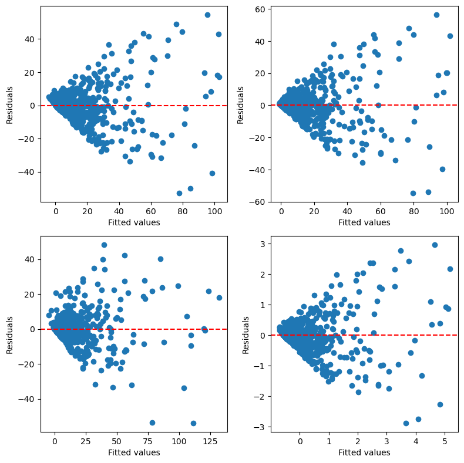

```python
fig, axes = plt.subplots(2, 2, figsize=(8, 8))
axes = axes.ravel()  # Flatten the 4x2 grid into a 1D array for easier iteration

models = [model, model_vif, model_int, model_pca]

for i, model_i in enumerate(models):
    ax = axes[i]
    residuals = model_i.resid
    fitted_values = model_i.fittedvalues
    ax.scatter(fitted_values, residuals)
    ax.axhline(y=0, color='r', linestyle='--')
    ax.set_xlabel('Fitted values')
    ax.set_ylabel('Residuals')

# Adjust layout to prevent overlap
plt.tight_layout()
```

```python
bp_test = het_breuschpagan(model.resid, model.model.exog)
print(f"Breusch-Pagan p-value: {bp_test[1]}")
```

```
Breusch-Pagan p-value: 8.543893545414126e-107
```

The cone shape present in the four models means heteroscedasticity, as the variance increases as the fitted values increase. Also, the Breusch-Pagan test rejects the null hypothesis (homoscedasticity).

We have tested some ways of addressing this, as performing Weighted Least Squares or transforming our predicted variable, but performance was still similar, as we can see here:

```python
residuals = model_vif.resid

weights = 1 / (residuals**2)
model_wls = sm.WLS(y_train, X_train, weights=weights).fit()
print(model_wls.summary())
```

```
                             WLS Regression Results
===============================================================================
Dep. Variable:     market_value_in_eur   R-squared:                       0.997
Model:                             WLS   Adj. R-squared:                  0.997
Method:                  Least Squares   F-statistic:                 6.746e+04
Date:                 Sun, 15 Dec 2024   Prob (F-statistic):               0.00
Time:                         23:14:36   Log-Likelihood:                -2273.2
No. Observations:                 1059   AIC:                             4558.
Df Residuals:                     1053   BIC:                             4588.
Df Model:                            5
Covariance Type:             nonrobust
===============================================================================================
                                  coef    std err          t      P>|t|      [0.025      0.975]
-----------------------------------------------------------------------------------------------
const                          -0.8632      0.017    -50.751      0.000      -0.897      -0.830
goals                           0.2247      0.003     71.342      0.000       0.218       0.231
assists                         0.4475      0.003    129.711      0.000       0.441       0.454
highest_market_value_in_eur  4.141e-07   1.16e-09    356.056      0.000    4.12e-07    4.16e-07
cl_matches                      0.1383      0.002     67.179      0.000       0.134       0.142
clean_sheet                    -0.0550      0.002    -22.134      0.000      -0.060      -0.050
==============================================================================
Omnibus:                     4740.399   Durbin-Watson:                   1.918
Prob(Omnibus):                  0.000   Jarque-Bera (JB):              165.062
Skew:                          -0.390   Prob(JB):                     1.44e-36
Kurtosis:                       1.230   Cond. No.                     2.87e+07
==============================================================================

Notes:
[1] Standard Errors assume that the covariance matrix of the errors is correctly specified.
[2] The condition number is large, 2.87e+07. This might indicate that there are
strong multicollinearity or other numerical problems.
```

```python
y_pred_wls = model_wls.predict(X_test)
r2_test_wls = r2_score(y_test, y_pred_wls)
print(f"Test R^2 for WLS: {r2_test_wls}")
```

```
Test R^2 for WLS: 0.7039730085424453
```

```python
model_rob = model_vif.get_robustcov_results()
```

### Conclusions

Let's analyze the final results of our model:

```python
print(model_rob.summary())
```

```
                             OLS Regression Results
===============================================================================
Dep. Variable:     market_value_in_eur   R-squared:                       0.758
Model:                             OLS   Adj. R-squared:                  0.757
Method:                  Least Squares   F-statistic:                     94.64
Date:                 Sun, 15 Dec 2024   Prob (F-statistic):           2.17e-82
Time:                         23:14:36   Log-Likelihood:                -3806.6
No. Observations:                 1059   AIC:                             7625.
Df Residuals:                     1053   BIC:                             7655.
Df Model:                            5
Covariance Type:                   HC1
===============================================================================================
                                  coef    std err          t      P>|t|      [0.025      0.975]
-----------------------------------------------------------------------------------------------
const                          -0.9144      0.466     -1.961      0.050      -1.829       0.001
goals                           0.2224      0.106      2.094      0.036       0.014       0.431
assists                         0.4518      0.236      1.911      0.056      -0.012       0.916
highest_market_value_in_eur  4.124e-07   4.48e-08      9.208      0.000    3.25e-07       5e-07
cl_matches                      0.1410      0.050      2.812      0.005       0.043       0.239
clean_sheet                    -0.0469      0.114     -0.411      0.681      -0.271       0.177
==============================================================================
Omnibus:                      216.842   Durbin-Watson:                   2.004
Prob(Omnibus):                  0.000   Jarque-Bera (JB):             4463.555
Skew:                           0.343   Prob(JB):                         0.00
Kurtosis:                      13.034   Cond. No.                     6.22e+07
==============================================================================

Notes:
[1] Standard Errors are heteroscedasticity robust (HC1)
[2] The condition number is large, 6.22e+07. This might indicate that there are
strong multicollinearity or other numerical problems.
```

Multiplying the coefficients corresponding to *highest_market_value_in_eur* so they are easier to understand (we are using millions of euros as unit):

```python
summary_table = model_rob.summary().tables[1]
summary_df = pd.read_html(StringIO(summary_table.as_html()), header=0, index_col=0)[0]
summary_df.at['highest_market_value_in_eur', 'coef'] *= 10**6
summary_df.at['highest_market_value_in_eur', 'std err'] *= 10**6
summary_df.at['highest_market_value_in_eur', '[0.025'] *= 10**6
summary_df.at['highest_market_value_in_eur', '0.975]'] *= 10**6
summary_df
```

|  | coef | std err | t | P>\|t\| | [0.025 | 0.975] |
| --- | --- | --- | --- | --- | --- | --- |
| const | -0.9144 | 0.4660 | -1.961 | 0.050 | -1.829 | 0.001 |
| goals | 0.2224 | 0.1060 | 2.094 | 0.036 | 0.014 | 0.431 |
| assists | 0.4518 | 0.2360 | 1.911 | 0.056 | -0.012 | 0.916 |
| highest_market_value_in_eur | 0.4124 | 0.0448 | 9.208 | 0.000 | 0.325 | 0.500 |
| cl_matches | 0.1410 | 0.0500 | 2.812 | 0.005 | 0.043 | 0.239 |
| clean_sheet | -0.0469 | 0.1140 | -0.411 | 0.681 | -0.271 | 0.177 |

**Confidence intervals**

We can plot the coefficients with the corresponding 95% confidence intervals to visuallize them:

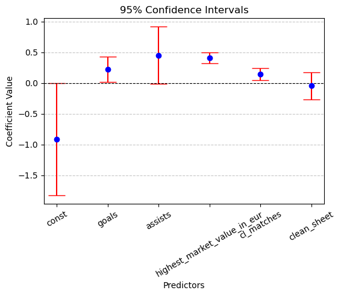

```python
# Data from the table
variables = summary_df.index
means = summary_df['coef']

conf_intervals = list(zip(summary_df['[0.025'], summary_df['0.975]']))

# Calculate error bars (distance from mean to lower/upper bound)
errors = np.array([[mean - ci[0], ci[1] - mean] for mean, ci in zip(means, conf_intervals)]).T

# Create the plot
plt.figure(figsize=(6, 4))
plt.errorbar(variables, means, yerr=errors, fmt='o', capsize=10, color='b', ecolor='r')

# Add labels and title
plt.xticks(rotation=30)
plt.axhline(0, color='black', linestyle='--', linewidth=0.8)
plt.title('95% Confidence Intervals')
plt.ylabel('Coefficient Value')
plt.xlabel('Predictors')
plt.grid(axis='y', linestyle='--', alpha=0.7)
```

We can see how positively correlated *goals*, *assists*, *highest_market_value_in_eur* and *cl_matches* are with our predicted variable, each of them with different confidence intervals (let's highlight how narrow the confidence interval of *highest_market_value_in_eur*, showing us how important for prediction the past values of a player are).

**Statistical significance**

```python
print('Statistical significances:')
print(f"    const: {summary_df['P>|t|'].loc['const']}")
print(f"    goals: {summary_df['P>|t|'].loc['goals']}")
print(f"    assists: {summary_df['P>|t|'].loc['assists']}")
print(f"    highest_market_value_in_eur: {summary_df['P>|t|'].loc['highest_market_value_in_eur']}")
print(f"    cl_matches: {summary_df['P>|t|'].loc['cl_matches']}")
print(f"    clean_sheet: {summary_df['P>|t|'].loc['clean_sheet']}")
```

```
Statistical significances:
    const: 0.05
    goals: 0.036
    assists: 0.056
    highest_market_value_in_eur: 0.0
    cl_matches: 0.005
    clean_sheet: 0.681
```

We see that the significant variables are *goals*, *highest_market_value_in_eur* and *cl_matches*, while *assists* and the constant maybe are significant but no by much, and *clean_sheet* does not seem to be significant for our model.

Some steps could be done to improve the performance of the model. First of all, collecting more data and creating a more general model could help us understand better the market value of players with different positions, leagues or that have played in other seasons. Also, more stats could be collected, like expected goals (the goals that a player "should" have scored). Finally, it is possible that the relation that this variables follow is not completely linear. For example, we know that the best players in the world can cost up to hundreds of millions of euros, differing their market value with other players by two orders of magnitude. However, their stats do not differ by two orders of magnitude: if a striker with a value of one million score 3 goals in a season, a striker that costs 100 million cannot score 300 goals.

In the next section, we are going to apply a GLM to a different dataset. However, at the end of the project there is an extra section that applies GLMs to this market value dataset, so we can see how GLMs can improve the performance of OLS.

## 2. GLM

In this part of the project, we are going to predict something very different to the market value of players: the classification (or not) of a club to one os the three european football competitions: Champions League (UCL), Europa League (UEL) or Conference League (UECL).

### Data preparation

The data for this part will be obtained through the website *Football Reference*: https://fbref.com/en/comps/Big5/Big-5-European-Leagues-Stats. It has been downloaded in the corresponding Kaggle page: https://www.kaggle.com/datasets/vivovinco/20212022-football-team-stats. Also, we have created a small dataset manually that has the classifications of the different clubs for each year.

#### Importing the data

First of all, we are going to import our 3 dataframes. The first two of them have information for each club of the big 5 european leagues (LaLiga from Spain, Premier League from England, Bundesliga from Germany, Serie A from Italy and Ligue 1 from France) and for the seasons 21-22 and 22-23, respectively. The other dataframe is the one that we have created, that contains the clubs from these leagues that classified to some european competition in these two seasons.

```python
club_stats_21_22 = pd.read_csv('club_stats_21_22.csv')
club_stats_22_23 = pd.read_csv('club_stats_22_23.csv')

europe_clubs = pd.read_csv('clubs_europe_classifications.csv')
```

Taking a look at the dataframe with the stats for the clubs, we can see that it provides information of matches played, goals scored, goals scored against, expected goals or attendance.

```python
club_stats_21_22.head()
```

|  | Unnamed: 0 | Rk | Squad | Country | LgRk | MP | W | D | L | GF | GA | GD | Pts | Pts/G | xG | xGA | xGD | xGD/90 | Attendance | Top Team Scorer | Goalkeeper |
| --- | --- | --- | --- | --- | --- | --- | --- | --- | --- | --- | --- | --- | --- | --- | --- | --- | --- | --- | --- | --- | --- |
| 0 | 0 | 1 | Manchester City | ENG | 1 | 38 | 29 | 6 | 3 | 99 | 26 | 73 | 93 | 2.45 | 89.0 | 27.2 | 61.9 | 1.63 | 52774 | Kevin De Bruyne - 15 | Ederson |
| 1 | 1 | 2 | Liverpool | ENG | 2 | 38 | 28 | 8 | 2 | 94 | 26 | 68 | 92 | 2.42 | 89.2 | 34.2 | 55.0 | 1.45 | 53367 | Mohamed Salah - 23 | Alisson |
| 2 | 2 | 3 | Bayern Munich | GER | 1 | 34 | 24 | 5 | 5 | 97 | 37 | 60 | 77 | 2.26 | 88.1 | 37.1 | 51.0 | 1.50 | 33176 | Robert Lewandowski - 35 | Manuel Neuer |
| 3 | 3 | 4 | Paris S-G | FRA | 1 | 38 | 26 | 8 | 4 | 90 | 36 | 54 | 86 | 2.26 | 76.5 | 38.6 | 37.9 | 1.00 | 41188 | Kylian Mbappé - 28 | Keylor Navas |
| 4 | 4 | 5 | Real Madrid | ESP | 1 | 38 | 26 | 8 | 4 | 80 | 31 | 49 | 86 | 2.26 | 74.3 | 47.0 | 27.3 | 0.72 | 41235 | Karim Benzema - 27 | Thibaut Courtois |

Our dataframe is very simple, and contains the competition in which a team classified for seasons 21-22 (2021) and 22-23 (2022).

```python
europe_clubs.head()
```

|  | Club | 2021 | 2022 |
| --- | --- | --- | --- |
| 0 | Real Madrid | UCL | UCL |
| 1 | Barcelona | UCL | UCL |
| 2 | Atlético Madrid | UCL | UCL |
| 3 | Sevilla | UCL | NaN |
| 4 | Betis | UEL | UEL |

#### Preparing the data

Let's do a union between the stats from both seasons. Looking at their columns:

```python
club_stats_21_22.columns
```

```
Index(['Unnamed: 0', 'Rk', 'Squad', 'Country', 'LgRk', 'MP', 'W', 'D', 'L',
       'GF', 'GA', 'GD', 'Pts', 'Pts/G', 'xG', 'xGA', 'xGD', 'xGD/90',
       'Attendance', 'Top Team Scorer', 'Goalkeeper'],
      dtype='object')
```

```python
club_stats_22_23.columns
```

```
Index(['Unnamed: 0', 'Rk', 'Squad', 'Country', 'LgRk', 'MP', 'W', 'D', 'L',
       'GF', 'GA', 'GD', 'Pts', 'Pts/MP', 'xG', 'xGA', 'xGD', 'xGD/90',
       'Attendance', 'Top Team Scorer', 'Goalkeeper'],
      dtype='object')
```

```python
club_stats_21_22 = club_stats_21_22.rename(columns={'Pts/G': 'Pts/MP'})
```

Add the season column:

```python
club_stats_21_22['Season'] = 2021
club_stats_22_23['Season'] = 2022
```

```python
club_stats_21_22.head()
```

|  | Unnamed: 0 | Rk | Squad | Country | LgRk | MP | W | D | L | GF | GA | GD | Pts | Pts/MP | xG | xGA | xGD | xGD/90 | Attendance | Top Team Scorer | Goalkeeper | Season |
| --- | --- | --- | --- | --- | --- | --- | --- | --- | --- | --- | --- | --- | --- | --- | --- | --- | --- | --- | --- | --- | --- | --- |
| 0 | 0 | 1 | Manchester City | ENG | 1 | 38 | 29 | 6 | 3 | 99 | 26 | 73 | 93 | 2.45 | 89.0 | 27.2 | 61.9 | 1.63 | 52774 | Kevin De Bruyne - 15 | Ederson | 2021 |
| 1 | 1 | 2 | Liverpool | ENG | 2 | 38 | 28 | 8 | 2 | 94 | 26 | 68 | 92 | 2.42 | 89.2 | 34.2 | 55.0 | 1.45 | 53367 | Mohamed Salah - 23 | Alisson | 2021 |
| 2 | 2 | 3 | Bayern Munich | GER | 1 | 34 | 24 | 5 | 5 | 97 | 37 | 60 | 77 | 2.26 | 88.1 | 37.1 | 51.0 | 1.50 | 33176 | Robert Lewandowski - 35 | Manuel Neuer | 2021 |
| 3 | 3 | 4 | Paris S-G | FRA | 1 | 38 | 26 | 8 | 4 | 90 | 36 | 54 | 86 | 2.26 | 76.5 | 38.6 | 37.9 | 1.00 | 41188 | Kylian Mbappé - 28 | Keylor Navas | 2021 |
| 4 | 4 | 5 | Real Madrid | ESP | 1 | 38 | 26 | 8 | 4 | 80 | 31 | 49 | 86 | 2.26 | 74.3 | 47.0 | 27.3 | 0.72 | 41235 | Karim Benzema - 27 | Thibaut Courtois | 2021 |

```python
# Do the union
club_stats = pd.concat([club_stats_21_22, club_stats_22_23])
club_stats = club_stats.rename(columns={'Squad': 'Club'})
print(f'{len(club_stats_21_22)} + {len(club_stats_22_23)} = {len(club_stats)}')
```

```
98 + 98 = 196
```

```python
club_stats.head()
```

|  | Unnamed: 0 | Rk | Club | Country | LgRk | MP | W | D | L | GF | GA | GD | Pts | Pts/MP | xG | xGA | xGD | xGD/90 | Attendance | Top Team Scorer | Goalkeeper | Season |
| --- | --- | --- | --- | --- | --- | --- | --- | --- | --- | --- | --- | --- | --- | --- | --- | --- | --- | --- | --- | --- | --- | --- |
| 0 | 0 | 1 | Manchester City | ENG | 1 | 38 | 29 | 6 | 3 | 99 | 26 | 73 | 93 | 2.45 | 89.0 | 27.2 | 61.9 | 1.63 | 52774 | Kevin De Bruyne - 15 | Ederson | 2021 |
| 1 | 1 | 2 | Liverpool | ENG | 2 | 38 | 28 | 8 | 2 | 94 | 26 | 68 | 92 | 2.42 | 89.2 | 34.2 | 55.0 | 1.45 | 53367 | Mohamed Salah - 23 | Alisson | 2021 |
| 2 | 2 | 3 | Bayern Munich | GER | 1 | 34 | 24 | 5 | 5 | 97 | 37 | 60 | 77 | 2.26 | 88.1 | 37.1 | 51.0 | 1.50 | 33176 | Robert Lewandowski - 35 | Manuel Neuer | 2021 |
| 3 | 3 | 4 | Paris S-G | FRA | 1 | 38 | 26 | 8 | 4 | 90 | 36 | 54 | 86 | 2.26 | 76.5 | 38.6 | 37.9 | 1.00 | 41188 | Kylian Mbappé - 28 | Keylor Navas | 2021 |
| 4 | 4 | 5 | Real Madrid | ESP | 1 | 38 | 26 | 8 | 4 | 80 | 31 | 49 | 86 | 2.26 | 74.3 | 47.0 | 27.3 | 0.72 | 41235 | Karim Benzema - 27 | Thibaut Courtois | 2021 |

Now, let's join to this dataframe the information of the competitions:

```python
europe_clubs.head()
```

|  | Club | 2021 | 2022 |
| --- | --- | --- | --- |
| 0 | Real Madrid | UCL | UCL |
| 1 | Barcelona | UCL | UCL |
| 2 | Atlético Madrid | UCL | UCL |
| 3 | Sevilla | UCL | NaN |
| 4 | Betis | UEL | UEL |

Melting the dataframe so we have a *Competition* column:

```python
europe_clubs_melted = europe_clubs.melt(id_vars='Club', var_name='Season', value_name='Competition')
europe_clubs_melted['Season'] = europe_clubs_melted['Season'].astype(int)
europe_clubs_melted.head()
```

|  | Club | Season | Competition |
| --- | --- | --- | --- |
| 0 | Real Madrid | 2021 | UCL |
| 1 | Barcelona | 2021 | UCL |
| 2 | Atlético Madrid | 2021 | UCL |
| 3 | Sevilla | 2021 | UCL |
| 4 | Betis | 2021 | UEL |

```python
# Do the join
club_stats = club_stats.merge(europe_clubs_melted, on=['Club', 'Season'], how='left')
club_stats.head()
```

|  | Unnamed: 0 | Rk | Club | Country | LgRk | MP | W | D | L | GF | GA | GD | Pts | Pts/MP | xG | xGA | xGD | xGD/90 | Attendance | Top Team Scorer | Goalkeeper | Season | Competition |
| --- | --- | --- | --- | --- | --- | --- | --- | --- | --- | --- | --- | --- | --- | --- | --- | --- | --- | --- | --- | --- | --- | --- | --- |
| 0 | 0 | 1 | Manchester City | ENG | 1 | 38 | 29 | 6 | 3 | 99 | 26 | 73 | 93 | 2.45 | 89.0 | 27.2 | 61.9 | 1.63 | 52774 | Kevin De Bruyne - 15 | Ederson | 2021 | UCL |
| 1 | 1 | 2 | Liverpool | ENG | 2 | 38 | 28 | 8 | 2 | 94 | 26 | 68 | 92 | 2.42 | 89.2 | 34.2 | 55.0 | 1.45 | 53367 | Mohamed Salah - 23 | Alisson | 2021 | UCL |
| 2 | 2 | 3 | Bayern Munich | GER | 1 | 34 | 24 | 5 | 5 | 97 | 37 | 60 | 77 | 2.26 | 88.1 | 37.1 | 51.0 | 1.50 | 33176 | Robert Lewandowski - 35 | Manuel Neuer | 2021 | UCL |
| 3 | 3 | 4 | Paris S-G | FRA | 1 | 38 | 26 | 8 | 4 | 90 | 36 | 54 | 86 | 2.26 | 76.5 | 38.6 | 37.9 | 1.00 | 41188 | Kylian Mbappé - 28 | Keylor Navas | 2021 | UCL |
| 4 | 4 | 5 | Real Madrid | ESP | 1 | 38 | 26 | 8 | 4 | 80 | 31 | 49 | 86 | 2.26 | 74.3 | 47.0 | 27.3 | 0.72 | 41235 | Karim Benzema - 27 | Thibaut Courtois | 2021 | UCL |

Let's create dummy variables for each of the competitions:

```python
# Create dummy variables for UCL, UEL, UECL
dummies = pd.get_dummies(club_stats['Competition'], dummy_na=False)

# Add a column for 'No Competition'
club_stats['No Competition'] = club_stats['Competition'].isna().astype(int)

# Join dummies into the original DataFrame
club_stats = pd.concat([club_stats, dummies], axis=1)

# Ensure all dummy columns are included
for col in ['UCL', 'UEL', 'UECL']:
    if col not in club_stats:
        club_stats[col] = 0
    else:
        club_stats[col] = club_stats[col].astype(int)
```

```python
club_stats.head()
```

|  | Unnamed: 0 | Rk | Club | Country | LgRk | MP | W | D | L | GF | GA | GD | Pts | Pts/MP | xG | xGA | xGD | xGD/90 | Attendance | Top Team Scorer | Goalkeeper | Season | Competition | No Competition | UCL | UECL | UEL |
| --- | --- | --- | --- | --- | --- | --- | --- | --- | --- | --- | --- | --- | --- | --- | --- | --- | --- | --- | --- | --- | --- | --- | --- | --- | --- | --- | --- |
| 0 | 0 | 1 | Manchester City | ENG | 1 | 38 | 29 | 6 | 3 | 99 | 26 | 73 | 93 | 2.45 | 89.0 | 27.2 | 61.9 | 1.63 | 52774 | Kevin De Bruyne - 15 | Ederson | 2021 | UCL | 0 | 1 | 0 | 0 |
| 1 | 1 | 2 | Liverpool | ENG | 2 | 38 | 28 | 8 | 2 | 94 | 26 | 68 | 92 | 2.42 | 89.2 | 34.2 | 55.0 | 1.45 | 53367 | Mohamed Salah - 23 | Alisson | 2021 | UCL | 0 | 1 | 0 | 0 |
| 2 | 2 | 3 | Bayern Munich | GER | 1 | 34 | 24 | 5 | 5 | 97 | 37 | 60 | 77 | 2.26 | 88.1 | 37.1 | 51.0 | 1.50 | 33176 | Robert Lewandowski - 35 | Manuel Neuer | 2021 | UCL | 0 | 1 | 0 | 0 |
| 3 | 3 | 4 | Paris S-G | FRA | 1 | 38 | 26 | 8 | 4 | 90 | 36 | 54 | 86 | 2.26 | 76.5 | 38.6 | 37.9 | 1.00 | 41188 | Kylian Mbappé - 28 | Keylor Navas | 2021 | UCL | 0 | 1 | 0 | 0 |
| 4 | 4 | 5 | Real Madrid | ESP | 1 | 38 | 26 | 8 | 4 | 80 | 31 | 49 | 86 | 2.26 | 74.3 | 47.0 | 27.3 | 0.72 | 41235 | Karim Benzema - 27 | Thibaut Courtois | 2021 | UCL | 0 | 1 | 0 | 0 |

This is the distribution of clubs:

```python
print(f'Clubs: {len(club_stats)} -> UCL: {len(club_stats[club_stats['UCL'] == 1])}, UEL: {len(club_stats[club_stats['UEL'] == 1])}, UECL: {len(club_stats[club_stats['UECL'] == 1])}, No competition: {len(club_stats[club_stats['No Competition'] == 1])}')
```

```
Clubs: 196 -> UCL: 36, UEL: 18, UECL: 10, No competition: 132
```

Now, let's create some variables that can be interesting for us:

- Goals per match played: *GF/MP*, *GF/MP*
- Accuracies: based on the goals and the expected goals, which is a stat that measures the goals that should have been scored.
- Leagues: dummy variables for each of the 5 leagues.

```python
club_stats['GF/MP'] = club_stats['GF']/club_stats['MP']
club_stats['GA/MP'] = club_stats['GA']/club_stats['MP']
club_stats['Accuracy'] = club_stats['GF']/club_stats['xG']
club_stats['Rival_Accuracy'] = club_stats['GA']/club_stats['xGA']

club_stats['LaLiga'] = club_stats['Country'].apply(lambda x: 1 if 'ESP' in x else 0)
club_stats['Premier'] = club_stats['Country'].apply(lambda x: 1 if 'ENG' in x else 0)
club_stats['SerieA'] = club_stats['Country'].apply(lambda x: 1 if 'ITA' in x else 0)
club_stats['Bundes'] = club_stats['Country'].apply(lambda x: 1 if 'GER' in x else 0)
club_stats['Ligue1'] = club_stats['Country'].apply(lambda x: 1 if 'FRA' in x else 0)
```

Our final dataset is ready:

```python
club_stats.head()
```

|  | Unnamed: 0 | Rk | Club | Country | LgRk | MP | W | D | L | GF | GA | GD | Pts | Pts/MP | xG | xGA | xGD | xGD/90 | Attendance | Top Team Scorer | Goalkeeper | Season | Competition | No Competition | UCL | UECL | UEL | GF/MP | GA/MP | … |
| --- | --- | --- | --- | --- | --- | --- | --- | --- | --- | --- | --- | --- | --- | --- | --- | --- | --- | --- | --- | --- | --- | --- | --- | --- | --- | --- | --- | --- | --- | --- |
| 0 | 0 | 1 | Manchester City | ENG | 1 | 38 | 29 | 6 | 3 | 99 | 26 | 73 | 93 | 2.45 | 89.0 | 27.2 | 61.9 | 1.63 | 52774 | Kevin De Bruyne - 15 | Ederson | 2021 | UCL | 0 | 1 | 0 | 0 | 2.605263 | 0.684211 | … |
| 1 | 1 | 2 | Liverpool | ENG | 2 | 38 | 28 | 8 | 2 | 94 | 26 | 68 | 92 | 2.42 | 89.2 | 34.2 | 55.0 | 1.45 | 53367 | Mohamed Salah - 23 | Alisson | 2021 | UCL | 0 | 1 | 0 | 0 | 2.473684 | 0.684211 | … |
| 2 | 2 | 3 | Bayern Munich | GER | 1 | 34 | 24 | 5 | 5 | 97 | 37 | 60 | 77 | 2.26 | 88.1 | 37.1 | 51.0 | 1.50 | 33176 | Robert Lewandowski - 35 | Manuel Neuer | 2021 | UCL | 0 | 1 | 0 | 0 | 2.852941 | 1.088235 | … |
| 3 | 3 | 4 | Paris S-G | FRA | 1 | 38 | 26 | 8 | 4 | 90 | 36 | 54 | 86 | 2.26 | 76.5 | 38.6 | 37.9 | 1.00 | 41188 | Kylian Mbappé - 28 | Keylor Navas | 2021 | UCL | 0 | 1 | 0 | 0 | 2.368421 | 0.947368 | … |
| 4 | 4 | 5 | Real Madrid | ESP | 1 | 38 | 26 | 8 | 4 | 80 | 31 | 49 | 86 | 2.26 | 74.3 | 47.0 | 27.3 | 0.72 | 41235 | Karim Benzema - 27 | Thibaut Courtois | 2021 | UCL | 0 | 1 | 0 | 0 | 2.105263 | 0.815789 | … |

### Data exploration

Let's check the correlation between variables:

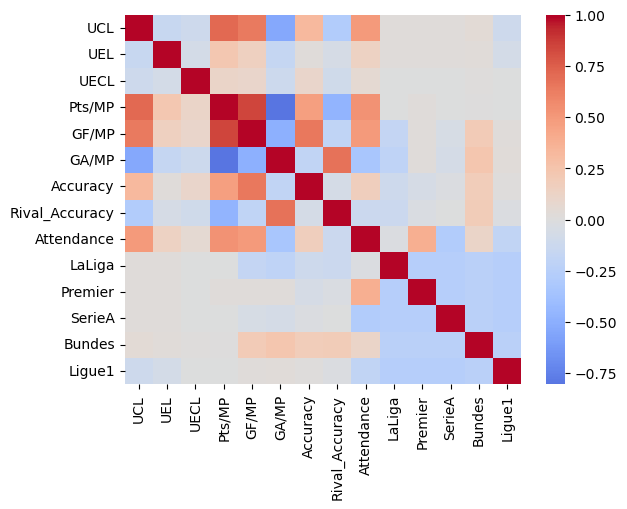

```python
corr_columns = ['UCL', 'UEL', 'UECL', 'Pts/MP', 'GF/MP', 'GA/MP', 'Accuracy', 'Rival_Accuracy', 'Attendance', 'LaLiga', 'Premier', 'SerieA', 'Bundes', 'Ligue1']
sns.heatmap(club_stats[corr_columns].corr(), cmap='coolwarm', center=0)
```

We see that correlation of UCL with some variables is considerable, while with the other competitions correlations are not strong. We will select these variables as our predictors:

```python
glm_columns = ['UCL', 'UEL', 'UECL', 'Pts/MP', 'GF/MP', 'GA/MP', 'Accuracy', 'Rival_Accuracy', 'Attendance']
glm_predicted = ['UCL', 'UEL', 'UECL']
#glm_predictors = [item for item in glm_columns if item not in glm_predicted]
glm_predictors = ['GF/MP', 'GA/MP', 'Accuracy', 'Rival_Accuracy', 'Attendance']

club_stats_glm = club_stats[glm_columns]
```

Plotting scatterplots for UCL we can visuallize these correlations:

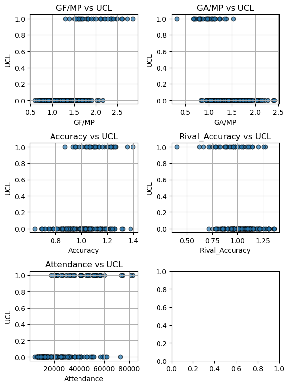

```python
# Set up the 4x2 grid
fig, axes = plt.subplots(3, 2, figsize=(6, 8))
axes = axes.ravel()  # Flatten the 4x2 grid into a 1D array for easier iteration

# Create scatterplots
for i, col in enumerate(glm_predictors):
    ax = axes[i]
    ax.scatter(club_stats_glm[col], club_stats_glm['UCL'], alpha=0.7, edgecolor='k')
    ax.set_title(f'{col} vs UCL')
    ax.set_xlabel(col)
    ax.set_ylabel('UCL')
    ax.grid(True)

# Adjust layout to prevent overlap
plt.tight_layout()
```

And looking at the distributions of the predictors, we see that they follow roughly gaussian distributions, except for attendance (it is skewed).

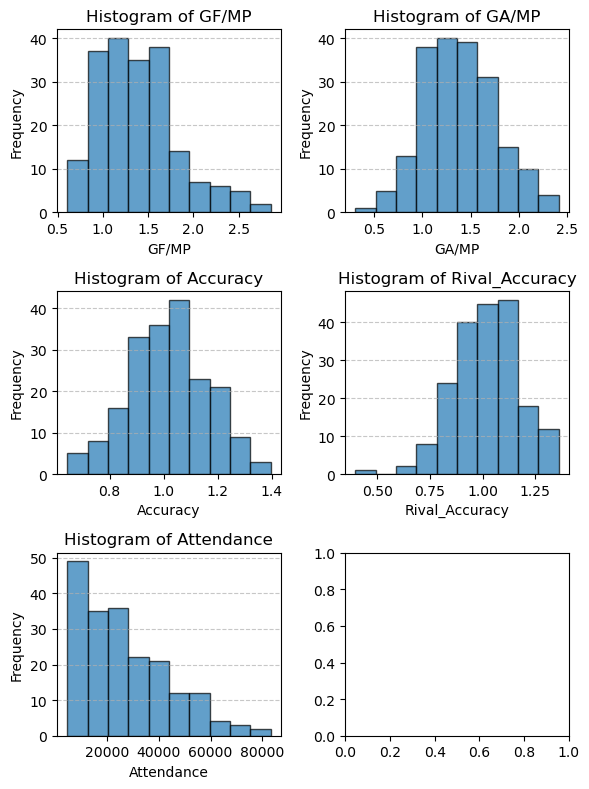

```python
# Set up the 4x2 grid for histograms
fig, axes = plt.subplots(3, 2, figsize=(6, 8))
axes = axes.ravel()  # Flatten the 4x2 grid into a 1D array for easier iteration

# Create histograms
for i, col in enumerate(glm_predictors):  # Use the same `x_columns` from before
    ax = axes[i]
    ax.hist(club_stats_glm[col], bins=10, edgecolor='k', alpha=0.7)
    ax.set_title(f'Histogram of {col}')
    ax.set_xlabel(col)
    ax.set_ylabel('Frequency')
    ax.grid(axis='y', linestyle='--', alpha=0.7)

# Adjust layout to prevent overlap
plt.tight_layout()
plt.show()
```

### Models

Our dataframe for the GLM will be this one, with the 3 dependent variables and the predictors:

```python
club_stats_glm['Attendance'] = club_stats_glm['Attendance']/10**5
club_stats_glm.head()
```

|  | UCL | UEL | UECL | Pts/MP | GF/MP | GA/MP | Accuracy | Rival_Accuracy | Attendance |
| --- | --- | --- | --- | --- | --- | --- | --- | --- | --- |
| 0 | 1 | 0 | 0 | 2.45 | 2.605263 | 0.684211 | 1.112360 | 0.955882 | 0.52774 |
| 1 | 1 | 0 | 0 | 2.42 | 2.473684 | 0.684211 | 1.053812 | 0.760234 | 0.53367 |
| 2 | 1 | 0 | 0 | 2.26 | 2.852941 | 1.088235 | 1.101022 | 0.997305 | 0.33176 |
| 3 | 1 | 0 | 0 | 2.26 | 2.368421 | 0.947368 | 1.176471 | 0.932642 | 0.41188 |
| 4 | 1 | 0 | 0 | 2.26 | 2.105263 | 0.815789 | 1.076716 | 0.659574 | 0.41235 |

For the predictive analysis, we are going to start with UCL competition, as it is the most important one. Then, we will compare its performance with UEL and UECL predictions. Finally, we will apply this models to a real life case, LaLiga 2022 season, so we can understand better the possibilities and limitations of the models.

#### Adressing correlation between predictors

Before starting with our UCL prediction, we will do a quick analysis of the multicolinearity of our dataset with the VIF:

```python
glm_predictors = ['GF/MP', 'GA/MP', 'Accuracy', 'Rival_Accuracy', 'Attendance']

vif_data = pd.DataFrame()
vif_data["feature"] = glm_predictors
vif_data["VIF"] = [variance_inflation_factor(club_stats_glm[glm_predictors].values, i) for i in range(club_stats_glm[glm_predictors].shape[1])]
print(vif_data)
```

```
          feature        VIF
0           GF/MP  30.415074
1           GA/MP  37.439837
2        Accuracy  60.964188
3  Rival_Accuracy  67.770291
4      Attendance   4.785414
```

We are going to drop the accuracy values, as we see that they are highly correlated with the rest of them.

```python
glm_predictors = ['GF/MP', 'GA/MP', 'Attendance']

vif_data = pd.DataFrame()
vif_data["feature"] = glm_predictors
vif_data["VIF"] = [variance_inflation_factor(club_stats_glm[glm_predictors].values, i) for i in range(club_stats_glm[glm_predictors].shape[1])]
print(vif_data)
```

```
      feature       VIF
0       GF/MP  8.458155
1       GA/MP  4.482338
2  Attendance  4.643127
```

Although the accuracy values that we calculated could be interesting, we have found that their information is contained in the goals per match scored variables. However, these variables are the most important ones for a team, as understanding them better can help a manager take strategy decision. Let's do the UCL model.

#### UCL prediction

```python
X = club_stats_glm[glm_predictors]
y = club_stats_glm['UCL']

X = sm.add_constant(X)

X_train, X_test, y_train, y_test = train_test_split(X, y, test_size = 0.2, random_state = 1)
```

As the outcome is binary (either you classify to UCL or you do not), we will use the Binomial family.

```python
# Fit a GLM with binomial family
glm_model = sm.GLM(y_train, X_train, family=sm.families.Binomial()).fit()

# Print summary
print(glm_model.summary())
```

```
                 Generalized Linear Model Regression Results
==============================================================================
Dep. Variable:                    UCL   No. Observations:                  156
Model:                            GLM   Df Residuals:                      152
Model Family:                Binomial   Df Model:                            3
Link Function:                  Logit   Scale:                          1.0000
Method:                          IRLS   Log-Likelihood:                -20.549
Date:                Sun, 15 Dec 2024   Deviance:                       41.098
Time:                        23:14:37   Pearson chi2:                     54.9
No. Iterations:                     8   Pseudo R-squ. (CS):             0.4821
Covariance Type:            nonrobust
==============================================================================
                 coef    std err          z      P>|z|      [0.025      0.975]
------------------------------------------------------------------------------
const         -2.2587      2.745     -0.823      0.411      -7.639       3.121
GF/MP          4.7556      1.453      3.272      0.001       1.907       7.604
GA/MP         -8.0632      2.287     -3.525      0.000     -12.546      -3.580
Attendance     7.2247      2.812      2.569      0.010       1.713      12.736
==============================================================================
```

##### Interpretation

```python
summary_table = glm_model.summary().tables[1]
summary_df = pd.read_html(StringIO(summary_table.as_html()), header=0, index_col=0)[0]
summary_df
```

|  | coef | std err | z | P>\|z\| | [0.025 | 0.975] |
| --- | --- | --- | --- | --- | --- | --- |
| const | -2.2587 | 2.745 | -0.823 | 0.411 | -7.639 | 3.121 |
| GF/MP | 4.7556 | 1.453 | 3.272 | 0.001 | 1.907 | 7.604 |
| GA/MP | -8.0632 | 2.287 | -3.525 | 0.000 | -12.546 | -3.580 |
| Attendance | 7.2247 | 2.812 | 2.569 | 0.010 | 1.713 | 12.736 |

**Confidence intervals**

We can plot the coefficients with the corresponding 95% confidence intervals to visuallize them:

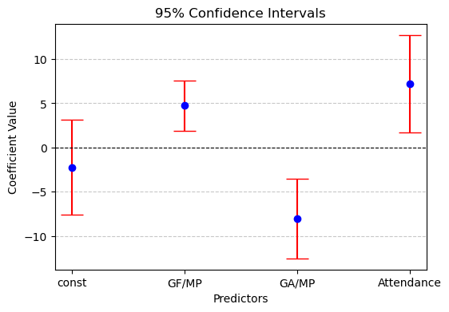

```python
# Data from the table
variables = summary_df.index
means = summary_df['coef']

conf_intervals = list(zip(summary_df['[0.025'], summary_df['0.975]']))

# Calculate error bars (distance from mean to lower/upper bound)
errors = np.array([[mean - ci[0], ci[1] - mean] for mean, ci in zip(means, conf_intervals)]).T

# Create the plot
plt.figure(figsize=(6, 4))
plt.errorbar(variables, means, yerr=errors, fmt='o', capsize=10, color='b', ecolor='r')

# Add labels and title
plt.axhline(0, color='black', linestyle='--', linewidth=0.8)
plt.title('95% Confidence Intervals')
plt.ylabel('Coefficient Value')
plt.xlabel('Predictors')
plt.grid(axis='y', linestyle='--', alpha=0.7)
```

And we can check also the individual effects of the predictors:

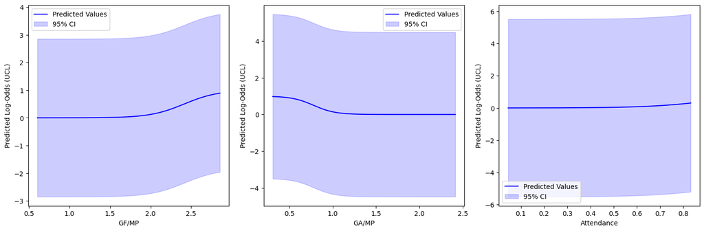

```python
fig, axes = plt.subplots(1, 3, figsize=(15, 5))
axes = axes.ravel()

# Create scatterplots
for i, predictor in enumerate(glm_predictors):

    linspace_data = np.linspace(club_stats_glm[predictor].min(), club_stats_glm[predictor].max(), len(club_stats_glm))

    predict_data = pd.DataFrame({
        'const': [1 for _ in range(len(club_stats_glm))],  # Add constant column
        'GF/MP': club_stats_glm['GF/MP'].mean(),
        'GA/MP': club_stats_glm['GA/MP'].mean(),
        #'Accuracy': club_stats_glm['Accuracy'].mean(),
        #'Rival_Accuracy': club_stats_glm['Rival_Accuracy'].mean(),
        'Attendance': club_stats_glm['Attendance'].mean()
    })

    predict_data[predictor] = linspace_data

    # Predict the fitted values and confidence intervals
    predicted_values = glm_model.predict(predict_data)

    # Calculate confidence intervals (approximate with standard errors)
    se = glm_model.bse[predictor]  # Standard error for GF/MP coefficient
    ci_lower = predicted_values - 1.96 * se
    ci_upper = predicted_values + 1.96 * se

    ax = axes[i]
    ax.plot(linspace_data, predicted_values, label='Predicted Values', color='blue')
    ax.fill_between(linspace_data, ci_lower, ci_upper, color='blue', alpha=0.2, label='95% CI')
    ax.set_xlabel(predictor)
    ax.set_ylabel("Predicted Log-Odds (UCL)")
    ax.legend()

# Adjust layout to prevent overlap
plt.tight_layout()
```

**Statistical significance**

```python
print('Statistical significances:')
print(f"    const: {summary_df['P>|z|'].loc['const']}")
print(f"    GF/MP: {summary_df['P>|z|'].loc['GF/MP']}")
print(f"    GA/MP: {summary_df['P>|z|'].loc['GA/MP']}")
print(f"    Attendance: {summary_df['P>|z|'].loc['Attendance']}")
```

```
Statistical significances:
    const: 0.411
    GF/MP: 0.001
    GA/MP: 0.0
    Attendance: 0.01
```

While the intercept (the constant) is not significant, we see that the three predictors are highly significant for the classification to UCL. Let's analize the odd ratios for these predictors:

**Odd ratios**

As the coefficients represent log odds, we are going to calculate the odd ratios:

```python
print('Odds ratios with std errors:')
print(f"GF/MP: {np.exp(summary_df['coef'].loc['GF/MP'])} ± {np.exp(summary_df['std err'].loc['GF/MP'])}")
print(f"GA/MP: {np.exp(summary_df['coef'].loc['GA/MP'])} ± {np.exp(summary_df['std err'].loc['GA/MP'])}")
print(f"Attendance: {np.exp(summary_df['coef'].loc['Attendance'])} ± {np.exp(summary_df['std err'].loc['Attendance'])}")
```

```
Odds ratios with std errors:
GF/MP: 116.23337226993789 ± 4.275923061928054
GA/MP: 0.0003149174553458314 ± 9.845357260945317
Attendance: 1372.9266758385602 ± 16.643171297218345
```

However, we see that for every additional goal conceded per match, the odds of classification are 0.03% as high (again, holding other variables constant). Comparing the original coefficients, we see that scoring a goal is not as important as not being scored one, roughly speaking. This shows how important defense is in football, as not receiving goals is one of the most important facts that can lead a team to the top of the classification. It is very difficult to be in the top of your league if you usually received a goal or more in each match.

The conclusion that could be extracted by manager and team directors is to focus on the defense on the team and, when this is secure, then you can start improving the attack. This is the strategy that many football managers follow, and it creates very solid teams that can classify to the top competitions.

**Predictions**

As this is a probabilistic model, we are going to assign a threshold of $P \ge 0.5$ for the prediction:

```python
# Prediction
y_pred_prob = glm_model.predict(X_test)

# The prediction is 1 if the probability is greater or equal than 0.5
y_pred = (y_pred_prob >= 0.5).astype(int)

# Confusion Matrix gives us the true and false positive and negatives
cm = confusion_matrix(y_test, y_pred)
print(f'True negatives: {cm[0,0]}. False negatives: {cm[1,0]}.')
print(f'True positives: {cm[1,1]}. False positives: {cm[0,1]}.')
print(f"Predicted {cm[1,1]} from { cm[1,1]+cm[1,0] } classifications.")

# Accuracy
#accuracy = accuracy_score(y_test, y_pred)
#print("Accuracy:", accuracy)
```

```
True negatives: 29. False negatives: 3.
True positives: 6. False positives: 2.
Predicted 6 from 9 classifications.
```

Some possible improvements could be to take into account the differences between leagues, as countries like France usually have less places for classification than countries like England or Spain. Also, other data could be added in order to improve the performance, like the market valuation of the squad. We have seen in the first part of the project how we could do this.

#### UEL and UECL prediction

Now we will do a quick analysis of UEL and UECL competitions and see how the performances are.

**UEL**

```python
X = club_stats_glm[glm_predictors]
y = club_stats_glm['UEL']
X = sm.add_constant(X)

X_train, X_test, y_train, y_test = train_test_split(X, y, test_size = 0.2, random_state = 1)

glm_model = sm.GLM(y_train, X_train, family=sm.families.Binomial())
glm_results = glm_model.fit()

print(glm_results.summary())
```

```
                 Generalized Linear Model Regression Results
==============================================================================
Dep. Variable:                    UEL   No. Observations:                  156
Model:                            GLM   Df Residuals:                      152
Model Family:                Binomial   Df Model:                            3
Link Function:                  Logit   Scale:                          1.0000
Method:                          IRLS   Log-Likelihood:                -41.241
Date:                Sun, 15 Dec 2024   Deviance:                       82.482
Time:                        23:14:38   Pearson chi2:                     125.
No. Iterations:                     6   Pseudo R-squ. (CS):            0.04394
Covariance Type:            nonrobust
==============================================================================
                 coef    std err          z      P>|z|      [0.025      0.975]
------------------------------------------------------------------------------
const         -1.2301      2.045     -0.602      0.547      -5.238       2.778
GF/MP          0.9836      0.778      1.264      0.206      -0.542       2.509
GA/MP         -1.6357      1.048     -1.560      0.119      -3.691       0.419
Attendance    -1.8177      2.163     -0.840      0.401      -6.057       2.421
==============================================================================
```

```python
y_pred_prob = glm_results.predict(X_test)
y_pred = (y_pred_prob >= 0.5).astype(int)

# Confusion Matrix
cm = confusion_matrix(y_test, y_pred)
#print("Confusion Matrix:\n", cm)
print(f'True negatives: {cm[0,0]}. False negatives: {cm[1,0]}.')
print(f'True positives: {cm[1,1]}. False positives: {cm[0,1]}.')
print(f"Predicted {cm[1,1]} from { cm[1,1]+cm[1,0] } classifications.")
```

```
True negatives: 35. False negatives: 5.
True positives: 0. False positives: 0.
Predicted 0 from 5 classifications.
```

**UECL**

```python
X = club_stats_glm[glm_predictors]
y = club_stats_glm['UECL']
X = sm.add_constant(X)

X_train, X_test, y_train, y_test = train_test_split(X, y, test_size = 0.2, random_state = 1)

glm_model = sm.GLM(y_train, X_train, family=sm.families.Binomial())
glm_results = glm_model.fit()

print(glm_results.summary())
```

```
                 Generalized Linear Model Regression Results
==============================================================================
Dep. Variable:                   UECL   No. Observations:                  156
Model:                            GLM   Df Residuals:                      152
Model Family:                Binomial   Df Model:                            3
Link Function:                  Logit   Scale:                          1.0000
Method:                          IRLS   Log-Likelihood:                -27.292
Date:                Sun, 15 Dec 2024   Deviance:                       54.585
Time:                        23:14:38   Pearson chi2:                     135.
No. Iterations:                     6   Pseudo R-squ. (CS):            0.01622
Covariance Type:            nonrobust
==============================================================================
                 coef    std err          z      P>|z|      [0.025      0.975]
------------------------------------------------------------------------------
const         -3.0323      2.652     -1.143      0.253      -8.230       2.165
GF/MP          0.7410      1.008      0.735      0.462      -1.235       2.717
GA/MP         -0.9009      1.272     -0.708      0.479      -3.394       1.592
Attendance     0.2342      2.573      0.091      0.927      -4.809       5.278
==============================================================================
```

```python
y_pred_prob = glm_results.predict(X_test)
y_pred = (y_pred_prob >= 0.5).astype(int)

# Confusion Matrix
cm = confusion_matrix(y_test, y_pred)
#print("Confusion Matrix:\n", cm)
print(f'True negatives: {cm[0,0]}. False negatives: {cm[1,0]}.')
print(f'True positives: {cm[1,1]}. False positives: {cm[0,1]}.')
print(f"Predicted {cm[1,1]} from { cm[1,1]+cm[1,0] } classifications.")
```

```
True negatives: 37. False negatives: 3.
True positives: 0. False positives: 0.
Predicted 0 from 3 classifications.
```

##### Interpretation

As we can see, our model is not capable of predicting the classification for these competitions. Why?

Classification to UEL and UECL is achieve by classifying under the Champions places and over the mid table. For example, in the season 2022 of Premier League the 5th and the 6th teams classified to UEL while the 7th team classified to UECL. This means that it is very difficult to predict these places, as they have similar stats to the clubs that are near them. Also, stats like goals per match do not have a constant contribution to the outcome, as scoring more goals helps a team classify better, but this means that they have more probability of classifying to UCL, therefore not classifying to UEL or UECL.

While it is relatively easy to predict whether a team will classify to Champions, it is difficult to do it for other competitions.

#### LaLiga 2022 prediction

Let's apply our models to a real season. We will try to predict the classifications for the season 2022 of LaLiga training our model with the rest of data.

**UCL**

```python
X_train = club_stats_glm[(club_stats['Country'] != 'ESP') | (club_stats['Season'] != 2022)][glm_predictors]
y_train = club_stats_glm[(club_stats['Country'] != 'ESP') | (club_stats['Season'] != 2022)]['UCL']

X_test = club_stats_glm[(club_stats['Country'] == 'ESP') & (club_stats['Season'] == 2022)][glm_predictors]
y_test = club_stats_glm[(club_stats['Country'] == 'ESP') & (club_stats['Season'] == 2022)]['UCL']

X_train = sm.add_constant(X_train)
X_test = sm.add_constant(X_test)

glm_model = sm.GLM(y_train, X_train, family=sm.families.Binomial()).fit()

y_pred_prob = glm_model.predict(X_test)
y_pred_ucl = (y_pred_prob >= 0.5).astype(int)

laliga_22 = club_stats[(club_stats['Country'] == 'ESP') & (club_stats['Season'] == 2022)][['Club', 'Competition']]
laliga_22['UCL'] = y_pred_ucl
```

**UEL**

As we saw that the model could not predict UEL and UECL classifications, let's change the threshold probability to $P \ge 0.25$ to see how the results change:

```python
y_train = club_stats_glm[(club_stats['Country'] != 'ESP') | (club_stats['Season'] != 2022)]['UEL']
y_test = club_stats_glm[(club_stats['Country'] == 'ESP') & (club_stats['Season'] == 2022)]['UEL']

glm_model = sm.GLM(y_train, X_train, family=sm.families.Binomial()).fit()

y_pred_prob = glm_model.predict(X_test)
y_pred_uel = (y_pred_prob >= 0.25).astype(int)  # Change threshold

laliga_22['UEL'] = y_pred_uel
```

**UECL**

```python
y_train = club_stats_glm[(club_stats['Country'] != 'ESP') | (club_stats['Season'] != 2022)]['UECL']
y_test = club_stats_glm[(club_stats['Country'] == 'ESP') & (club_stats['Season'] == 2022)]['UECL']

glm_model = sm.GLM(y_train, X_train, family=sm.families.Binomial()).fit()

y_pred_prob = glm_model.predict(X_test)
y_pred_uecl = (y_pred_prob >= 0.25).astype(int)  # Change threshold

laliga_22['UECL'] = y_pred_uecl
```

**Final results**

```python
laliga_22
```

|  | Club | Competition | UCL | UEL | UECL |
| --- | --- | --- | --- | --- | --- |
| 98 | Barcelona | UCL | 1 | 1 | 0 |
| 103 | Real Madrid | UCL | 1 | 1 | 0 |
| 105 | Atlético Madrid | UCL | 1 | 0 | 0 |
| 117 | Real Sociedad | UCL | 0 | 0 | 0 |
| 126 | Villarreal | UEL | 0 | 0 | 0 |
| 129 | Betis | UEL | 0 | 0 | 0 |
| 133 | Athletic Club | NaN | 0 | 0 | 0 |
| 144 | Osasuna | UECL | 0 | 0 | 0 |
| 146 | Rayo Vallecano | NaN | 0 | 0 | 0 |
| 150 | Mallorca | NaN | 0 | 0 | 0 |
| 151 | Girona | NaN | 0 | 0 | 0 |
| 156 | Sevilla | NaN | 0 | 0 | 0 |
| 158 | Celta Vigo | NaN | 0 | 0 | 0 |
| 160 | Valladolid | NaN | 0 | 0 | 0 |
| 162 | Getafe | NaN | 0 | 0 | 0 |
| 164 | Cádiz | NaN | 0 | 0 | 0 |
| 174 | Almería | NaN | 0 | 0 | 0 |
| 176 | Valencia | NaN | 0 | 0 | 0 |
| 178 | Espanyol | NaN | 0 | 0 | 0 |
| 194 | Elche | NaN | 0 | 0 | 0 |

As we can see in the predictions, the model works reasonably fine for predicting UCL classifications. As classification is "continuous", meaning that there is not a big difference between the 4th and the 5th team in the league, it did not predict the classification of Real Sociedad (the 4th team). Fine tuning the model with more data about LaLiga could improve the performance. However, we see that UEL and UECL predictions are not satisfactory. As we said, a variable like goals scored is not lineally correlated to classifying to one of these competitions, as scoring more goals makes you classify to UCL, not UEL or UECL. For predicting this, other types of methods or data could be used.

### EXTRA: GLM for market value

As an extra analysis of this project, we are going to combine the two parts of it. We saw that the linear regression model for predicting the market value of players was satisfactory, but linear regression with that data could not be fitted completely well. This could be due to non-linearity in the dependent variable: the market value. As we have seen that the distribution of this variable is continuous, positive and skewed:

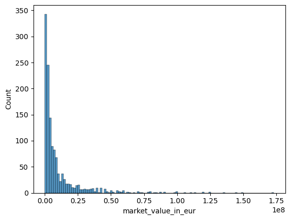

```python
sns.histplot(lr_df['market_value_in_eur'])
```

We can explore how a GLM would fit. For this type of data, we are going to explore three families: gamma distribution, inverse gaussian and the tweedie family, which is a distribution similar to gamma and poisson. We will compare them using the following parameters:

- AIC (Akaike information criterion): estimator of prediction error. Lower values -> better fits.
- Deviance: generalization of using the sum of square residuals in OLS. Lowe values -> better fits.
- Pearson $\chi^2$: evaluates residual goodness of fit. Lower values -> better fits.

```python
# Define data using the predictors from the VIF analysis
X = lr_df[new_predictors]
y = lr_df['market_value_in_eur']/10**6  # Market value in millions
X = sm.add_constant(X)

# Define our GLMs
models = {
    "Gamma (Log link)": sm.GLM(y, X, family=sm.families.Gamma(link=sm.families.links.Log())),
    "Inverse Gaussian (Log link)": sm.GLM(y, X, family=sm.families.InverseGaussian(link=sm.families.links.Log())),
    "Tweedie (Log link)": sm.GLM(y, X, family=sm.families.Tweedie(var_power=1.5, link=sm.families.links.Log())),  # var_power of 1.5 is typical for skewed continue data
}

# Fit
results = {}
for name, model in models.items():
    result = model.fit()
    results[name] = result

# Store parameters
performance = pd.DataFrame({
    "Model": list(results.keys()),
    "AIC": [res.aic for res in results.values()],
    "Deviance": [res.deviance for res in results.values()],
    "Pearson Chi2": [res.pearson_chi2 for res in results.values()]
})

print("\nPerformance Comparison:")
print(performance)
```

```
Performance Comparison:
                         Model          AIC     Deviance  Pearson Chi2
0             Gamma (Log link)  7281.303680  1133.775866    891.846888
1  Inverse Gaussian (Log link)  9766.350170   757.402512    230.246773
2           Tweedie (Log link)  7848.105435  2636.123663   2750.378593
```

The tweedie is clearly the worst model, as it has very high deviance and pearson $\chi^2$ and, while the inverse gaussian model has lower of these values compared with the gamma distribution, its high AIC value could indicate that it is overfitting. Because of this, we are going to investigate more the Gamma distribution model, as it is a relatively simple model but still fits well the data.

```python
X_train, X_test, y_train, y_test = train_test_split(X, y, test_size = 0.2, random_state = 1)

model_gamma = sm.GLM(y_train, X_train, family=sm.families.Gamma(link=sm.families.links.Log())).fit()
print(model_gamma.summary())
```

```
                  Generalized Linear Model Regression Results
===============================================================================
Dep. Variable:     market_value_in_eur   No. Observations:                 1059
Model:                             GLM   Df Residuals:                     1053
Model Family:                    Gamma   Df Model:                            5
Link Function:                     Log   Scale:                         0.67893
Method:                           IRLS   Log-Likelihood:                -2926.0
Date:                 Sun, 15 Dec 2024   Deviance:                       922.00
Time:                         23:14:38   Pearson chi2:                     715.
No. Iterations:                     37   Pseudo R-squ. (CS):             0.8119
Covariance Type:             nonrobust
===============================================================================================
                                  coef    std err          z      P>|z|      [0.025      0.975]
-----------------------------------------------------------------------------------------------
const                           0.7211      0.043     16.744      0.000       0.637       0.806
goals                           0.0154      0.007      2.230      0.026       0.002       0.029
assists                         0.0063      0.013      0.476      0.634      -0.020       0.032
highest_market_value_in_eur  3.073e-08   1.42e-09     21.668      0.000     2.8e-08    3.35e-08
cl_matches                      0.0020      0.002      0.937      0.349      -0.002       0.006
clean_sheet                     0.0557      0.008      7.290      0.000       0.041       0.071
===============================================================================================
```

In this model, we see that the key predictors are goals, highest market value and clean sheets; while the predictors assists and cl_matches are not significant. This means that players in clubs that have more clean sheets and have had a high market value are very valuated, and this increases with the goals scored after a season.

Numerically, every additional goals scored increases the market value by approximately $e^{0.0154} -1 \approx 1.55 \%$, every additional euro in the highest market value increases the market value by $e^{3.073 \times 10^{-8}} -1 \approx 3 \times 10^{-6} \%$ and every additional clean sheet increases the market value by $e^{0.0557} -1 \approx 5.73 \%$. Taking into account that the highest market value is usually in the order of $10^6$, this shows us how important are the past highest market value (as players depend heavily on their past), clean sheets (as players in good, defensive squads are more expensive) and the goals that an attackers scores in a season. Stats like assists, for example, are not significant.

We can check the distribution of residuals:

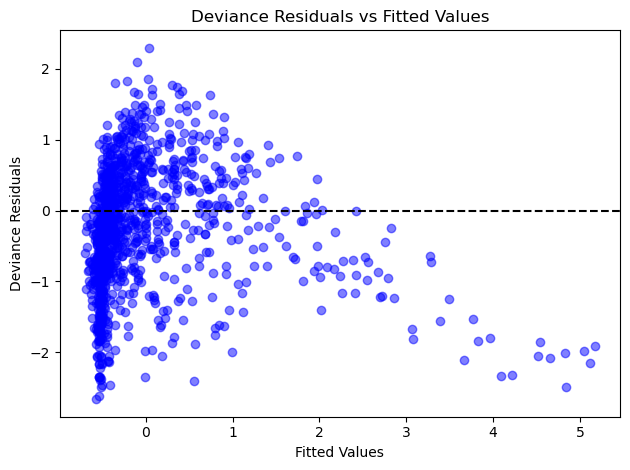

```python
dev_residuals = model_gamma.resid_deviance

plt.plot(figsize=(12,10))
plt.scatter(fitted_values, dev_residuals, color='blue', alpha=0.5)
plt.axhline(0, color='black', linestyle='--')
plt.title("Deviance Residuals vs Fitted Values")
plt.xlabel("Fitted Values")
plt.ylabel("Deviance Residuals")

plt.tight_layout()
plt.show()
```

We see that there is a more uniform distribution around zero compared with the residual plot of the linear regression model, meaning that probably the gamma distribution and the log link were good assumptions for our data. GLM are a great way to adress complex data predictions with simple models. However, this market value prediction probably could benefit quite a lot from more complex prediction methods that take into account the nuances of this data.